# Causes and Effects of Employee Downsizing: A Review and Synthesis

satisfaction and more favorable employer–

employee relations.

Creativity was lower than baseline levels at Wave 1,

at Wave 2, and at Wave 3. Productivity declined

from baseline levels at Wave 1 and Wave 2.

During downsizing there was a decrease in work

environment stimulants from baseline—freedom,

work challenge, supervisory encouragement, work

group support and resources available. On the

other hand, organization impediments and

workload pressure increased from baseline levels.

*(continued)*

Page 36

316

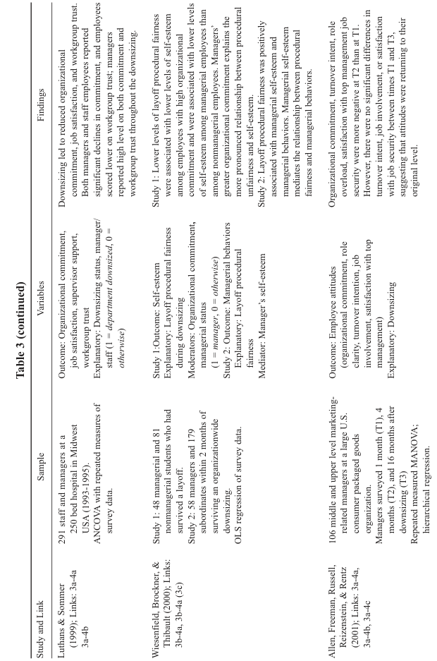

NOTE: figure/graphic rendered as an image from the PDF; its content is not machine-readable text. Caption (if any) follows as the next block.

**text found inside the figure**

Study and Link

Luthans & Sommer

(1999); Links: 3a-4a

3a-4b

Wiesenfield, Brockner, &

Thibault (2000); Links:

3b-4a, 3b-4a (3c)

Allen, Freeman, Russell,

Reizenstein, & Rentz

(2001); Links: 3a-4a,

3a-4b, 3a-4c

Sample

291 staff and managers at a 250 bed hospital in Midwest USA (1993-1995).

ANCOVA with repeated measures of

survey data.

Study 1: 48 managerial and 81

nonmanagerial students who had

survived a layoff.

Study 2: 58 managers and 179

subordinates within 2 months of

surviving an organizationwide

downsizing.

OLS regression of survey data.

106 middle and upper level marketingrelated managers at a large U.S.

consumer packaged goods

organization.

Managers surveyed 1 month (T1), 4

months (T2), and 16 months after

downsizing (T3)

Repeated measured MANOVA;

hierarchical regression.

Variables

Outcome: Organizational commitment,

job satisfaction, supervisor support,

workgroup trust

Explanatory: Downsizing status, manager/

staff (1 = *department downsized*, 0 =

*otherwise*)

Study 1:Outcome: Self-esteem

Explanatory: Layoff procedural fairness

during downsizing

Moderators: Organizational commitment**,**

managerial status

(1 = *manager*, 0 = *otherwise*)

Study 2: Outcome: Managerial behaviors

Explanatory: Layoff procedural

fairness

Mediator: Manager’s self-esteem

Outcome: Employee attitudes

(organizational commitment, role

clarity, turnover intention, job

involvement, satisfaction with top

management)

Explanatory: Downsizing

Findings

Downsizing led to reduced organizational

commitment, job satisfaction, and workgroup trust.

Both managers and staff employees reported

significant declines in commitment, and employees

scored lower on workgroup trust; managers

reported high level on both commitment and

workgroup trust throughout the downsizing.

Study 1: Lower levels of layoff procedural fairness

were associated with lower levels of self-esteem

among employees with high organizational

commitment and were associated with lower levels

of self-esteem among managerial employees than

among nonmanagerial employees. Managers’

greater organizational commitment explains the

more pronounced relationship between procedural

unfairness and self-esteem.

Study 2: Layoff procedural fairness was positively

associated with managerial self-esteem and

managerial behaviors. Managerial self-esteem

mediates the relationship between procedural

fairness and managerial behaviors.

Organizational commitment, turnover intent, role

overload, satisfaction with top management job

security were more negative at T2 than at T1.

However, there were no significant differences in

turnover intent, job involvement, or satisfaction

with job security between times T1 and T3,

suggesting that attitudes were returning to their

original level.

**Table 3 (continued)**

Page 37

317

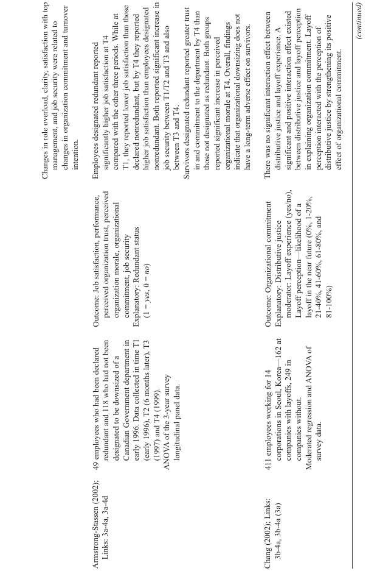

NOTE: figure/graphic rendered as an image from the PDF; its content is not machine-readable text. Caption (if any) follows as the next block.

**text found inside the figure**

Armstrong-Stassen (2002);

Links: 3a-4a, 3a-4d

Chang (2002); Links:

3b-4a, 3b-4a (3a)

49 employees who had been declared redundant and 118 who had not been

designated to be downsized of a

Canadian Government department in

early 1996. Data collected in time T1

(early 1996), T2 (6 months later), T3

(1997) and T4 (1999).

ANOVA of the 3-year survey

longitudinal panel data.

411 employees working for 14 corporations in Seoul, Korea—162 at

companies with layoffs, 249 in

companies without.

Moderated regression and ANOVA of

survey data.

Outcome: Job satisfaction, performance,

perceived organization trust, perceived

organization morale, organizational

commitment, job security

Explanatory: Redundant status

(1 = *yes*, 0 = *no*)

Outcome: Organizational commitment

Explanatory: Distributive justice

moderator: Layoff experience (yes/no),

Layoff perception—likelihood of a

layoff in the near future (0%, 1-20%,

21-40%, 41-60%, 61-80%, and 81-100%)

Changes in role overload, clarity, satisfaction with top

management, and job security were related to

changes in organization commitment and turnover

intention.

Employees designated redundant reported

significantly higher job satisfaction at T4

compared with the other three periods. While at

T1, they reported lower job satisfaction than those

declared nonredundant, but by T4 they reported

higher job satisfaction than employees designated

nonredundant. Both reported significant increase in

job security between T1/T2 and T3 and also

between T3 and T4.

Survivors designated redundant reported greater trust

in and commitment to the department by T4 than

those not designated as redundant. Both groups

reported significant increase in perceived

organizational morale at T4. Overall, findings

indicate that organizational downsizing does not

have a long-term adverse effect on survivors.

There was no significant interaction effect between

distributive justice and layoff experience. A

significant and positive interaction effect existed

between distributive justice and layoff perception

in explaining organization commitment. Layoff

perception interacted with the perception of

distributive justice by strengthening its positive

effect of organizational commitment.

*(continued)*

Page 38

318

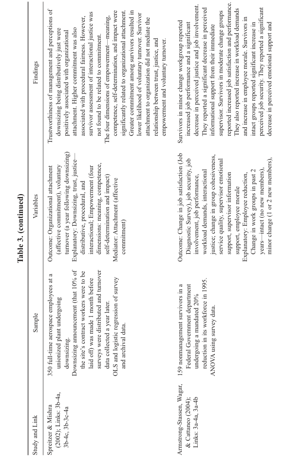

NOTE: figure/graphic rendered as an image from the PDF; its content is not machine-readable text. Caption (if any) follows as the next block.

**text found inside the figure**

Study and Link

Spreitzer & Mishra

(2002); Links: 3b-4a,

3b-4c, 3b-3c-4a

Armstrong-Stassen, Wagar,

& Cattaneo (2004);

Links: 3a-4a, 3a-4b

Sample

350 full-time aerospace employees at a unionized plant undergoing

downsizing.

Downsizing announcement (that 10% of

the site’s contract workers were to be

laid off) was made 1 month before

surveys were distributed and turnover

data collected a year later.

OLS and logistic regression of survey

and archival data.

159 nonmanagement survivors in a Federal Government department

undergoing a mandated 20%

reduction in its workforce in 1995.

ANOVA using survey data.

Variables

Outcome: Organizational attachment

(affective commitment), voluntary

turnover (a year following downsizing)

Explanatory: Downsizing, trust, justice—

distributive, procedural, and

interactional; Empowerment (four

dimensions: meaning, competence,

self-determination and impact)

Mediator: Attachment (affective

commitment)

Outcome: Change in job satisfaction (Job

Diagnostic Survey), job security, job

involvement, job performance,

workload demands, interactional

justice; change in group cohesiveness,

service quality, supervisor emotional

support, supervisor information

support, employee morale

Explanatory: Employee reduction,

Change in work groups in past 2

years—intact (no new members),

minor change (1 or 2 new members),

Findings

Trustworthiness of management and perceptions of

downsizing being distributively just were

positively associated with organizational

attachment. Higher commitment was also

associated with procedural fairness. However,

survivor assessment of interactional justice was

not found to be related to commitment.

The four dimensions of empowerment—meaning,

competence, self-determination, and impact were

significantly related to organizational attachment.

Greater commitment among survivors resulted in

lower likelihood of voluntary turnover. Survivor

attachment to organization did not mediate the

relationship between trust, justice, and

empowerment and voluntary turnover.

Survivors in minor change workgroup reported

increased job performance and a significant

decrease in perceived justice and job involvement.

They reported a significant decrease in perceived

informational support from their immediate

supervisor. Survivors in moderate change groups

reported increased job satisfaction and performance.

They also reported increase in workload demands

and increase in employee morale. Survivors in

intact groups reported significant increase in

perceived job security. They reported a significant

decrease in perceived emotional support and

**Table 3. (continued)**

Page 39

319

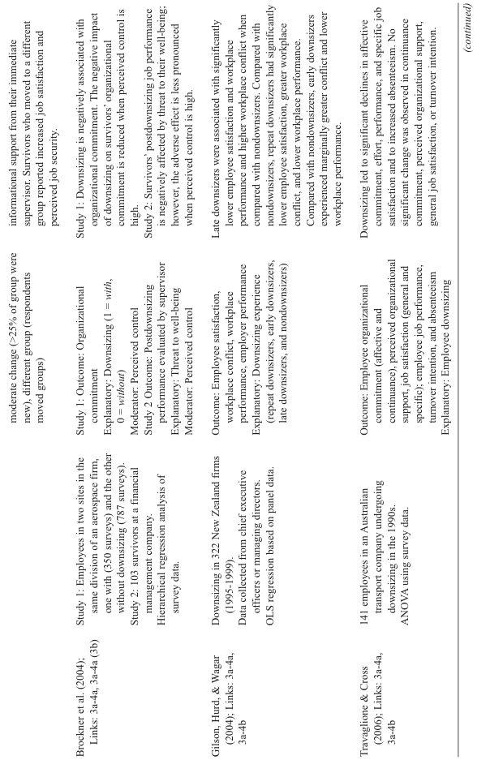

NOTE: figure/graphic rendered as an image from the PDF; its content is not machine-readable text. Caption (if any) follows as the next block.

**text found inside the figure**

Brockner et al. (2004);

Links: 3a-4a, 3a-4a (3b)

Gilson, Hurd, & Wagar

(2004); Links: 3a-4a,

3a-4b

Travaglione & Cross

(2006); Links: 3a-4a,

3a-4b

Study 1: Employees in two sites in the

same division of an aerospace firm,

one with (350 surveys) and the other

without downsizing (787 surveys).

Study 2: 103 survivors at a financial

management company.

Hierarchical regression analysis of

survey data.

Downsizing in 322 New Zealand firms

(1995-1999).

Data collected from chief executive

officers or managing directors.

OLS regression based on panel data.

141 employees in an Australian transport company undergoing

downsizing in the 1990s.

ANOVA using survey data.

moderate change (>25% of group were

new), different group (respondents

moved groups)

Study 1: Outcome: Organizational

commitment

Explanatory: Downsizing (1 = *with*,

0 = *without*) Moderator: Perceived control

Study 2 Outcome: Postdownsizing

performance evaluated by supervisor

Explanatory: Threat to well-being

Moderator: Perceived control

Outcome: Employee satisfaction,

workplace conflict, workplace

performance, employer performance

Explanatory: Downsizing experience

(repeat downsizers, early downsizers,

late downsizers, and nondownsizers)

Outcome: Employee organizational

commitment (affective and

continuance), perceived organizational

support, job satisfaction (general and

specific); employee job performance,

turnover intention, and absenteeism

Explanatory: Employee downsizing

informational support from their immediate

supervisor. Survivors who moved to a different

group reported increased job satisfaction and

perceived job security.

Study 1: Downsizing is negatively associated with

organizational commitment. The negative impact

of downsizing on survivors’ organizational

commitment is reduced when perceived control is

high.

Study 2: Survivors’ postdownsizing job performance

is negatively affected by threat to their well-being;

however, the adverse effect is less pronounced

when perceived control is high.

Late downsizers were associated with significantly

lower employee satisfaction and workplace

performance and higher workplace conflict when

compared with nondownsizers. Compared with

nondownsizers, repeat downsizers had significantly

lower employee satisfaction, greater workplace

conflict, and lower workplace performance.

Compared with nondownsizers, early downsizers

experienced marginally greater conflict and lower

workplace performance.

Downsizing led to significant declines in affective

commitment, effort, performance, and specific job

satisfaction and to increased absenteeism. No

significant change was observed in continuance

commitment, perceived organizational support,

general job satisfaction, or turnover intention.

*(continued)*

Page 40

320

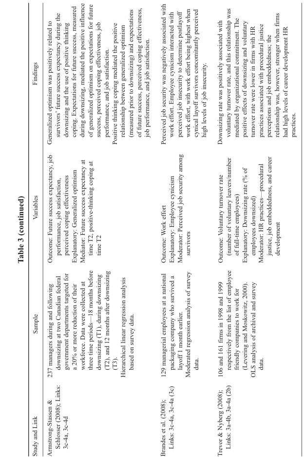

NOTE: complex table shown as an image of the PDF; the text below is a rough machine extraction and may be mis-aligned.

**extracted text (unreliable layout)**

**Table 3 (continued)**

Page 41

Datta et al. / Causes and Effects of Employee Downsizing 321

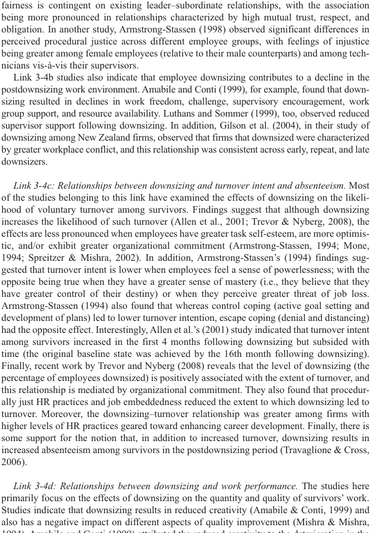

NOTE: figure/graphic rendered as an image from the PDF; its content is not machine-readable text. Caption (if any) follows as the next block.

**text found inside the figure**

fairness is contingent on existing leader–subordinate relationships, with the association being more pronounced in relationships characterized by high mutual trust, respect, and obligation. In another study, Armstrong-Stassen (1998) observed significant differences in perceived procedural justice across different employee groups, with feelings of injustice being greater among female employees (relative to their male counterparts) and among technicians vis-à-vis their supervisors.

Link 3-4b studies also indicate that employee downsizing contributes to a decline in the postdownsizing work environment. Amabile and Conti (1999), for example, found that downsizing resulted in declines in work freedom, challenge, supervisory encouragement, work group support, and resource availability. Luthans and Sommer (1999), too, observed reduced supervisor support following downsizing. In addition, Gilson et al. (2004), in their study of downsizing among New Zealand firms, observed that firms that downsized were characterized by greater workplace conflict, and this relationship was consistent across early, repeat, and late downsizers.

*Link 3-4c: Relationships between downsizing and turnover intent and absenteeism.* Most of the studies belonging to this link have examined the effects of downsizing on the likelihood of voluntary turnover among survivors. Findings suggest that although downsizing increases the likelihood of such turnover (Allen et al., 2001; Trevor & Nyberg, 2008), the effects are less pronounced when employees have greater task self-esteem, are more optimistic, and/or exhibit greater organizational commitment (Armstrong-Stassen, 1994; Mone, 1994; Spreitzer & Mishra, 2002). In addition, Armstrong-Stassen’s (1994) findings suggested that turnover intent is lower when employees feel a sense of powerlessness; with the opposite being true when they have a greater sense of mastery (i.e., they believe that they have greater control of their destiny) or when they perceive greater threat of job loss. Armstrong-Stassen (1994) also found that whereas control coping (active goal setting and development of plans) led to lower turnover intention, escape coping (denial and distancing) had the opposite effect. Interestingly, Allen et al.’s (2001) study indicated that turnover intent among survivors increased in the first 4 months following downsizing but subsided with time (the original baseline state was achieved by the 16th month following downsizing). Finally, recent work by Trevor and Nyberg (2008) reveals that the level of downsizing (the percentage of employees downsized) is positively associated with the extent of turnover, and this relationship is mediated by organizational commitment. They also found that procedurally just HR practices and job embeddedness reduced the extent to which downsizing led to turnover. Moreover, the downsizing–turnover relationship was greater among firms with higher levels of HR practices geared toward enhancing career development. Finally, there is some support for the notion that, in addition to increased turnover, downsizing results in increased absenteeism among survivors in the postdownsizing period (Travaglione & Cross, 2006).

*Link 3-4d: Relationships between downsizing and work performance.* The studies here primarily focus on the effects of downsizing on the quantity and quality of survivors’ work. Studies indicate that downsizing results in reduced creativity (Amabile & Conti, 1999) and also has a negative impact on different aspects of quality improvement (Mishra & Mishra, 1994). Amabile and Conti (1999) attributed the reduced creativity to the deterioration in the

Page 42

322 Journal of Management / January 2010

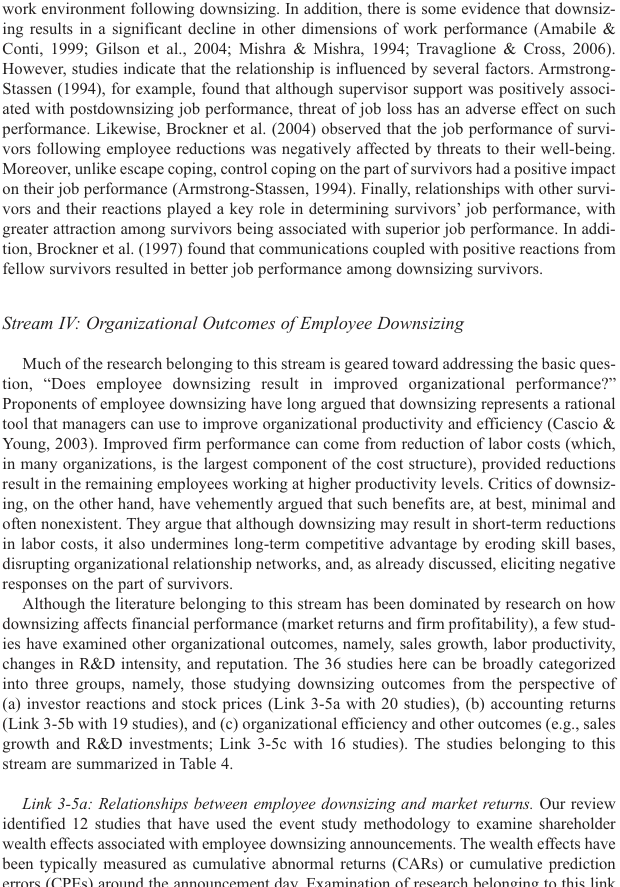

NOTE: figure/graphic rendered as an image from the PDF; its content is not machine-readable text. Caption (if any) follows as the next block.

**text found inside the figure**

work environment following downsizing. In addition, there is some evidence that downsizing results in a significant decline in other dimensions of work performance (Amabile & Conti, 1999; Gilson et al., 2004; Mishra & Mishra, 1994; Travaglione & Cross, 2006). However, studies indicate that the relationship is influenced by several factors. Armstrong- Stassen (1994), for example, found that although supervisor support was positively associated with postdownsizing job performance, threat of job loss has an adverse effect on such performance. Likewise, Brockner et al. (2004) observed that the job performance of survivors following employee reductions was negatively affected by threats to their well-being. Moreover, unlike escape coping, control coping on the part of survivors had a positive impact on their job performance (Armstrong-Stassen, 1994). Finally, relationships with other survivors and their reactions played a key role in determining survivors’ job performance, with greater attraction among survivors being associated with superior job performance. In addition, Brockner et al. (1997) found that communications coupled with positive reactions from fellow survivors resulted in better job performance among downsizing survivors.

*Stream IV: Organizational Outcomes of Employee Downsizing*

Much of the research belonging to this stream is geared toward addressing the basic question, “Does employee downsizing result in improved organizational performance?” Proponents of employee downsizing have long argued that downsizing represents a rational tool that managers can use to improve organizational productivity and efficiency (Cascio & Young, 2003). Improved firm performance can come from reduction of labor costs (which, in many organizations, is the largest component of the cost structure), provided reductions result in the remaining employees working at higher productivity levels. Critics of downsizing, on the other hand, have vehemently argued that such benefits are, at best, minimal and often nonexistent. They argue that although downsizing may result in short-term reductions in labor costs, it also undermines long-term competitive advantage by eroding skill bases, disrupting organizational relationship networks, and, as already discussed, eliciting negative responses on the part of survivors.

Although the literature belonging to this stream has been dominated by research on how downsizing affects financial performance (market returns and firm profitability), a few studies have examined other organizational outcomes, namely, sales growth, labor productivity, changes in R&D intensity, and reputation. The 36 studies here can be broadly categorized into three groups, namely, those studying downsizing outcomes from the perspective of (a) investor reactions and stock prices (Link 3-5a with 20 studies), (b) accounting returns (Link 3-5b with 19 studies), and (c) organizational efficiency and other outcomes (e.g., sales growth and R&D investments; Link 3-5c with 16 studies). The studies belonging to this stream are summarized in Table 4.

*(Text continues on p. 335)*

Page 43

323

**Table 4**

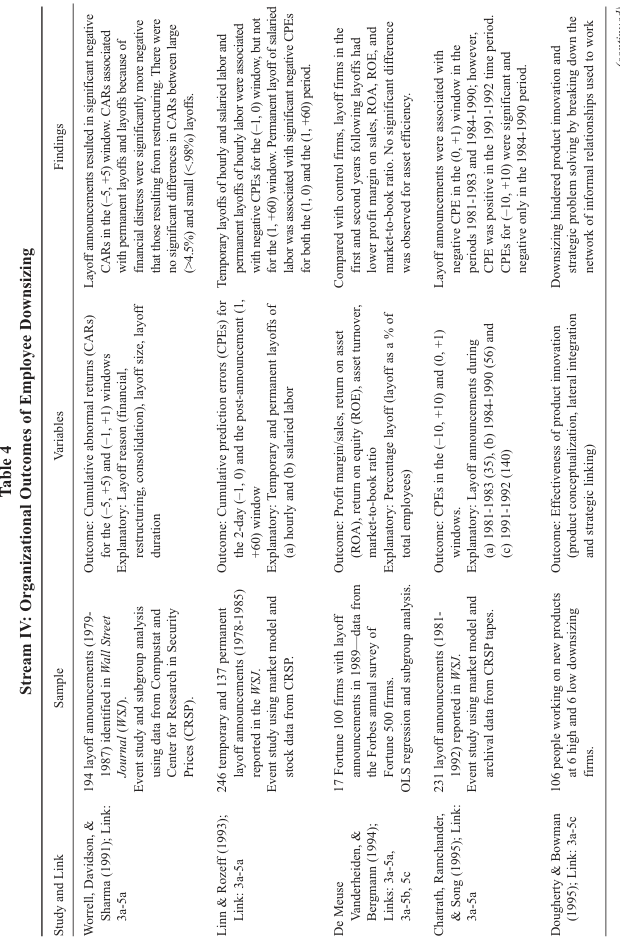

NOTE: figure/graphic rendered as an image from the PDF; its content is not machine-readable text. Caption (if any) follows as the next block.

**text found inside the figure**

**Stream IV: Organizational Outcomes of Employee Downsizing**

Study and Link

Worrell, Davidson, &

Sharma (1991); Link:

3a-5a

Linn & Rozeff (1993);

Link: 3a-5a

De Meuse

Vanderheiden, &

Bergmann (1994);

Links: 3a-5a,

3a-5b, 5c

Chatrath, Ramchander,

& Song (1995); Link:

3a-5a

Dougherty & Bowman

(1995); Link: 3a-5c

Sample

194 layoff announcements (1979- 1987) identified in *Wall Street Journal* (*WSJ*).

Event study and subgroup analysis

using data from Compustat and

Center for Research in Security

Prices (CRSP).

246 temporary and 137 permanent layoff announcements (1978-1985)

reported in the *WSJ*.

Event study using market model and

stock data from CRSP.

17 Fortune 100 firms with layoff announcements in 1989—data from

the Forbes annual survey of

Fortune 500 firms.

OLS regression and subgroup analysis.

231 layoff announcements (1981- 1992) reported in *WSJ*. Event study using market model and

archival data from CRSP tapes.

106 people working on new products at 6 high and 6 low downsizing

firms.

Variables

Outcome: Cumulative abnormal returns (CARs)

for the (–5, +5) and (–1, +1) windows

Explanatory: Layoff reason (financial,

restructuring, consolidation), layoff size, layoff

duration

Outcome: Cumulative prediction errors (CPEs) for

the 2-day (–1, 0) and the post-announcement (1,

+60) window

Explanatory: Temporary and permanent layoffs of

(a) hourly and (b) salaried labor

Outcome: Profit margin/sales, return on asset

(ROA), return on equity (ROE), asset turnover,

market-to-book ratio

Explanatory: Percentage layoff (layoff as a % of

total employees)

Outcome: CPEs in the (–10, +10) and (0, +1)

windows.

Explanatory: Layoff announcements during

(a) 1981-1983 (35), (b) 1984-1990 (56) and

(c) 1991-1992 (140)

Outcome: Effectiveness of product innovation

(product conceptualization, lateral integration

and strategic linking)

Findings

Layoff announcements resulted in significant negative

CARs in the (–5, +5) window. CARs associated

with permanent layoffs and layoffs because of

financial distress were significantly more negative

that those resulting from restructuring. There were

no significant differences in CARs between large

(>4.5%) and small (<.98%) layoffs.

Temporary layoffs of hourly and salaried labor and

permanent layoffs of hourly labor were associated

with negative CPEs for the (–1, 0) window, but not

for the (1, +60) window. Permanent layoff of salaried

labor was associated with significant negative CPEs

for both the (1, 0) and the (1, +60) period.

Compared with control firms, layoff firms in the

first and second years following layoffs had

lower profit margin on sales, ROA, ROE, and

market-to-book ratio. No significant difference

was observed for asset efficiency.

Layoff announcements were associated with

negative CPE in the (0, +1) window in the

periods 1981-1983 and 1984-1990; however,

CPE was positive in the 1991-1992 time period.

CPEs for (–10, +10) were significant and

negative only in the 1984-1990 period.

Downsizing hindered product innovation and

strategic problem solving by breaking down the

network of informal relationships used to work

*(continued)*

Page 44

324

**Table 4 (continued)**

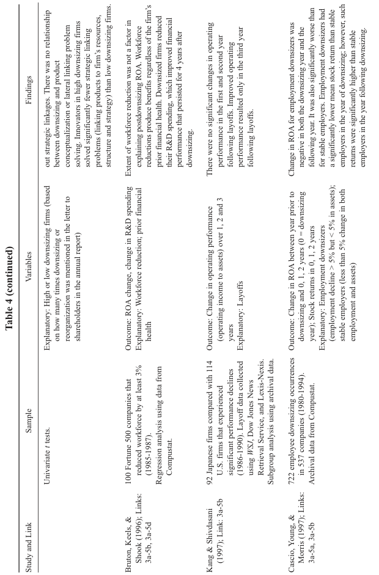

NOTE: figure/graphic rendered as an image from the PDF; its content is not machine-readable text. Caption (if any) follows as the next block.

**text found inside the figure**

Study and Link

Bruton, Keels, &

Shook (1996); Links:

3a-5b, 3a-5d

Kang & Shivdasani

(1997); Link: 3a-5b

Cascio, Young, &

Morris (1997); Links:

3a-5a, 3a-5b

Sample

Univariate *t* tests.

100 Fortune 500 companies that reduced workforce by at least 3%

(1985-1987).

Regression analysis using data from

Compustat.

92 Japanese firms compared with 114 U.S. firms that experienced

significant performance declines

(1986-1990). Layoff data collected

using *WSJ*, Dow Jones News

Retrieval Service, and Lexis-Nexis.

Subgroup analysis using archival data.

722 employee downsizing occurrences in 537 companies (1980-1994).

Archival data from Compustat.

Variables

Explanatory: High or low downsizing firms (based

on how many times downsizing or

reorganization was mentioned in the letter to

shareholders in the annual report)

Outcome: ROA change, change in R&D spending

Explanatory: Workforce reduction; prior financial

health

Outcome: Change in operating performance

(operating income to assets) over 1, 2 and 3

years

Explanatory: Layoffs

Outcome: Change in ROA between year prior to

downsizing and 0, 1, 2 years (0 = downsizing

year); Stock returns in 0, 1, 2 years

Explanatory: Employment downsizers

(employment decline > 5% but < 5% in assets);

stable employers (less than 5% change in both

employment and assets)

Findings

out strategic linkages. There was no relationship

between downsizing and product

conceptualization or lateral linking problem

solving. Innovators in high downsizing firms

solved significantly fewer strategic linking

problems (linking products to firm’s resources,

structure and strategy) than low downsizing firms.

Extent of workforce reduction was not a factor in

explaining postdownsizing ROA. Workforce

reductions produce benefits regardless of the firm’s

prior financial health. Downsized firms reduced

their R&D spending, which improved financial

performance that persisted for 4 years after

downsizing.

There were no significant changes in operating

performance in the first and second year

following layoffs. Improved operating

performance resulted only in the third year

following layoffs.

Change in ROA for employment downsizers was

negative in both the downsizing year and the

following year. It was also significantly worse than

for stable employers. Employment downsizers had

a significantly lower mean stock return than stable

employers in the year of downsizing; however, such

returns were significantly higher than stable

employers in the year following downsizing.

Page 45

325

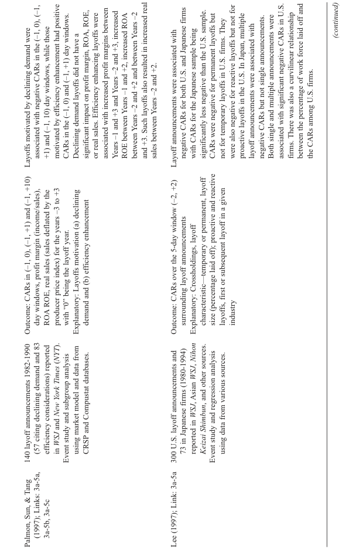

NOTE: figure/graphic rendered as an image from the PDF; its content is not machine-readable text. Caption (if any) follows as the next block.

**text found inside the figure**

Palmon, Sun, & Tang

(1997); Links: 3a-5a,

3a-5b, 3a-5c

Lee (1997); Link: 3a-5a

140 layoff announcements 1982-1990 (57 citing declining demand and 83

efficiency considerations) reported

in *WSJ* and *New York Times* (*NYT*).

Event study and subgroup analysis

using market model and data from

CRSP and Compustat databases.

300 U.S. layoff announcements and 73 in Japanese firms (1980-1994) reported in *WSJ*, Asian *WSJ*, *Nihon*

*Keizai Shimbun*, and other sources.

Event study and regression analysis

using data from various sources.

Outcome: CARs in (–1, 0), (–1, +1) and (–1, +10)

day windows, profit margin (income/sales),

ROA ROE, real sales (sales deflated by the

producer price index) for the years –3 to +3

with “0” being the layoff year.

Explanatory: Layoffs motivation (a) declining

demand and (b) efficiency enhancement

Outcome: CARs over the 5-day window (–2, +2)

surrounding layoff announcements

Explanatory: Crossholdings, layoff

characteristic—temporary or permanent, layoff

size (percentage laid off); proactive and reactive

layoffs, first or subsequent layoff in a given

industry

Layoffs motivated by declining demand were

associated with negative CARs in the (–1, 0), (–1,

+1) and (–1, 10) day windows, while those

motivated by efficiency enhancement had positive

CARs in the (–1, 0) and (–1, +1) day windows.

Declining demand layoffs did not have a

significant impact on profit margin, ROA, ROE,

or real sales. Efficiency enhancing layoffs were

associated with increased profit margins between

Years –1 and +3 and Years –2 and +3, increased

ROE between Years –1 and +2, increased ROA

between Years –2 and +2 and between Years –2

and +3. Such layoffs also resulted in increased real

sales between Years –2 and +2.

Layoff announcements were associated with

negative CARs for both U.S. and Japanese firms

with CARs for the Japanese sample being

significantly less negative than the U.S. sample.

CARs were negative for permanent layoffs but

not for temporary layoffs in U.S. firms. They

were also negative for reactive layoffs but not for

proactive layoffs in the U.S. In Japan, multiple

layoff announcements were associated with

negative CARs but not single announcements.

Both single and multiple announcements were

associated with significant negative CARs in U.S.

firms. There was also a curvilinear relationship

between the percentage of work force laid off and

the CARs among U.S. firms.

*(continued)*

Page 46

326

**Table 4 (continued)**

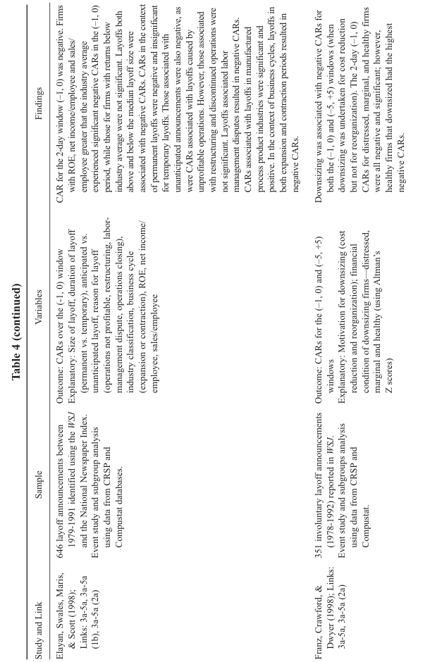

NOTE: figure/graphic rendered as an image from the PDF; its content is not machine-readable text. Caption (if any) follows as the next block.

**text found inside the figure**

Study and Link

Elayan, Swales, Maris,

& Scott (1998);

Links: 3a-5a, 3a-5a

(1b), 3a-5a (2a)

Franz, Crawford, &

Dwyer (1998); Links:

3a-5a, 3a-5a (2a)

Sample

646 layoff announcements between 1979-1991 identified using the *WSJ* and the National Newspaper Index.

Event study and subgroup analysis

using data from CRSP and

Compustat databases.

351 involuntary layoff announcements (1978-1992) reported in *WSJ*.

Event study and subgroups analysis

using data from CRSP and

Compustat.

Variables

Outcome: CARs over the (-1, 0) window

Explanatory: Size of layoff, duration of layoff

(permanent vs. temporary), anticipated vs.

unanticipated layoff, reason for layoff

(operations not profitable, restructuring, labor-

management dispute, operations closing),

industry classification, business cycle

(expansion or contraction), ROE, net income/

employee, sales/employee

Outcome: CARs for the (–1, 0) and (–5, +5)

windows

Explanatory: Motivation for downsizing (cost

reduction and reorganization); financial

condition of downsizing firms—distressed,

marginal and healthy (using Altman’s

Z scores)

Findings

CAR for the 2-day window (–1, 0) was negative. Firms

with ROE, net income/employee and sales/

employee greater that the industry average

experienced significant negative CARs in the (–1, 0)

period, while those for firms with returns below

industry average were not significant. Layoffs both

above and below the median layoff size were

associated with negative CARs. CARs in the context

of permanent layoffs were negative and insignificant

for temporary layoffs. Those associated with

unanticipated announcements were also negative, as

were CARs associated with layoffs caused by

unprofitable operations. However, those associated

with restructuring and discontinued operations were

not significant. Layoffs associated labor

management disputes resulted in negative CARs.

CARs associated with layoffs in manufactured

process product industries were significant and

positive. In the context of business cycles, layoffs in

both expansion and contraction periods resulted in

negative CARs.

Downsizing was associated with negative CARs for

both the (–1, 0) and (–5, +5) windows (when

downsizing was undertaken for cost reduction

but not for reorganization). The 2-day (–1, 0)

CARs for distressed, marginal, and healthy firms

were all negative and significant; however,

healthy firms that downsized had the highest

negative CARs.

Page 47

327

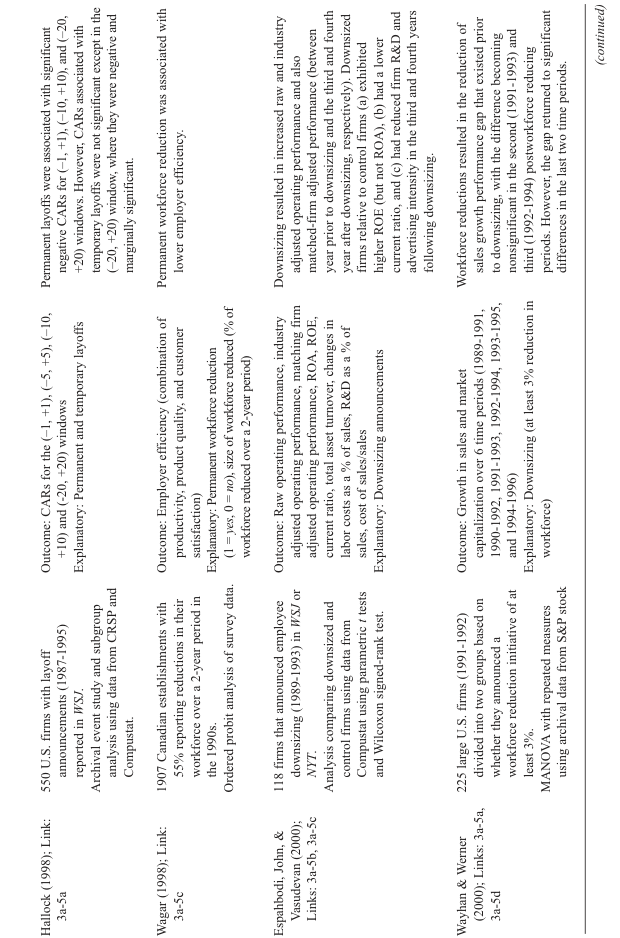

NOTE: figure/graphic rendered as an image from the PDF; its content is not machine-readable text. Caption (if any) follows as the next block.

**text found inside the figure**

Hallock (1998); Link:

3a-5a

Wagar (1998); Link:

3a-5c

Espahbodi, John, &

Vasudevan (2000);

Links: 3a-5b, 3a-5c

Wayhan & Werner

(2000); Links: 3a-5a,

3a-5d

550 U.S. firms with layoff announcements (1987-1995)

reported in *WSJ*.

Archival event study and subgroup

analysis using data from CRSP and

Compustat.

1907 Canadian establishments with 55% reporting reductions in their workforce over a 2-year period in

the 1990s.

Ordered probit analysis of survey data.

118 firms that announced employee downsizing (1989-1993) in *WSJ* or

*NYT*.

Analysis comparing downsized and

control firms using data from

Compustat using parametric *t* tests

and Wilcoxon signed-rank test.

225 large U.S. firms (1991-1992) divided into two groups based on

whether they announced a

workforce reduction initiative of at

least 3%.

MANOVA with repeated measures

using archival data from S&P stock

Outcome: CARs for the (–1, +1), (–5, +5), (–10,

+10) and (-20, +20) windows

Explanatory: Permanent and temporary layoffs

Outcome: Employer efficiency (combination of

productivity, product quality, and customer

satisfaction)

Explanatory: Permanent workforce reduction

(1 = *yes*, 0 = *no*), size of workforce reduced (% of

workforce reduced over a 2-year period)

Outcome: Raw operating performance, industry

adjusted operating performance, matching firm

adjusted operating performance, ROA, ROE,

current ratio, total asset turnover, changes in

labor costs as a % of sales, R&D as a % of

sales, cost of sales/sales

Explanatory: Downsizing announcements

Outcome: Growth in sales and market

capitalization over 6 time periods (1989-1991,

1990-1992, 1991-1993, 1992-1994, 1993-1995, and 1994-1996)

Explanatory: Downsizing (at least 3% reduction in

workforce)

Permanent layoffs were associated with significant

negative CARs for (–1, +1), (–10, +10), and (–20,

+20) windows. However, CARs associated with

temporary layoffs were not significant except in the

(–20, +20) window, where they were negative and

marginally significant.

Permanent workforce reduction was associated with

lower employer efficiency.

Downsizing resulted in increased raw and industry

adjusted operating performance and also

matched-firm adjusted performance (between

year prior to downsizing and the third and fourth

year after downsizing, respectively). Downsized

firms relative to control firms (a) exhibited

higher ROE (but not ROA), (b) had a lower

current ratio, and (c) had reduced firm R&D and

advertising intensity in the third and fourth years

following downsizing.

Workforce reductions resulted in the reduction of

sales growth performance gap that existed prior

to downsizing, with the difference becoming

nonsignificant in the second (1991-1993) and

third (1992-1994) postworkforce reducing

periods. However, the gap returned to significant

differences in the last two time periods.

*(continued)*

Page 48

328

**Table 4 (continued)**

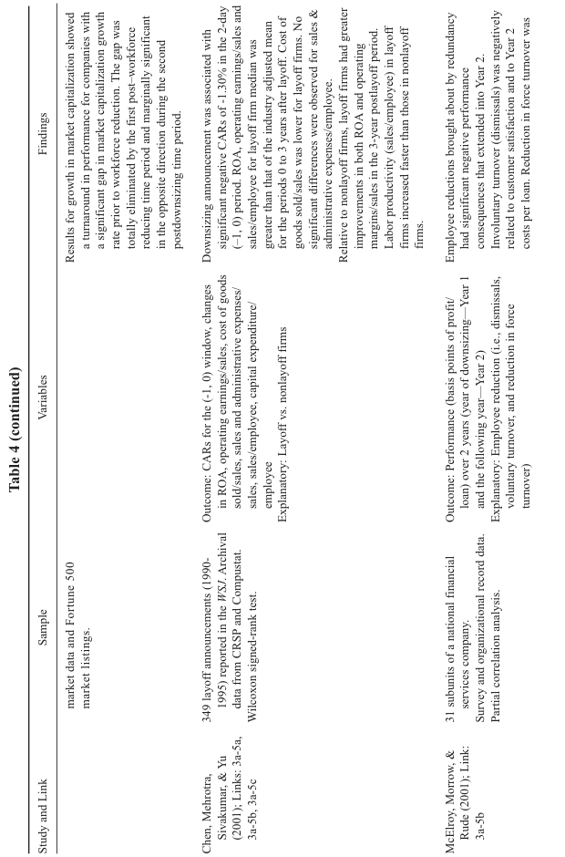

NOTE: figure/graphic rendered as an image from the PDF; its content is not machine-readable text. Caption (if any) follows as the next block.

**text found inside the figure**

Study and Link

Chen, Mehrotra,

Sivakumar, & Yu

(2001); Links: 3a-5a,

3a-5b, 3a-5c

McElroy, Morrow, &

Rude (2001); Link:

3a-5b

Sample

market data and Fortune 500

market listings.

349 layoff announcements (1990- 1995) reported in the *WSJ*. Archival data from CRSP and Compustat.

Wilcoxon signed-rank test.

31 subunits of a national financial services company.

Survey and organizational record data.

Partial correlation analysis.

Variables

Outcome: CARs for the (-1, 0) window, changes

in ROA, operating earnings/sales, cost of goods

sold/sales, sales and administrative expenses/

sales, sales/employee, capital expenditure/

employee

Explanatory: Layoff vs. nonlayoff firms

Outcome: Performance (basis points of profit/

loan) over 2 years (year of downsizing—Year 1

and the following year—Year 2)

Explanatory: Employee reduction (i.e., dismissals,

voluntary turnover, and reduction in force

turnover)

Findings

Results for growth in market capitalization showed

a turnaround in performance for companies with

a significant gap in market capitalization growth

rate prior to workforce reduction. The gap was

totally eliminated by the first post–workforce

reducing time period and marginally significant

in the opposite direction during the second

postdownsizing time period.

Downsizing announcement was associated with

significant negative CARs of -1.30% in the 2-day

(–1, 0) period. ROA, operating earnings/sales and

sales/employee for layoff firm median was

greater than that of the industry adjusted mean

for the periods 0 to 3 years after layoff. Cost of

goods sold/sales was lower for layoff firms. No

significant differences were observed for sales &

administrative expenses/employee.

Relative to nonlayoff firms, layoff firms had greater

improvements in both ROA and operating

margins/sales in the 3-year postlayoff period.

Labor productivity (sales/employee) in layoff

firms increased faster than those in nonlayoff

firms.

Employee reductions brought about by redundancy

had significant negative performance

consequences that extended into Year 2.

Involuntary turnover (dismissals) was negatively

related to customer satisfaction and to Year 2

costs per loan. Reduction in force turnover was

Page 49

329

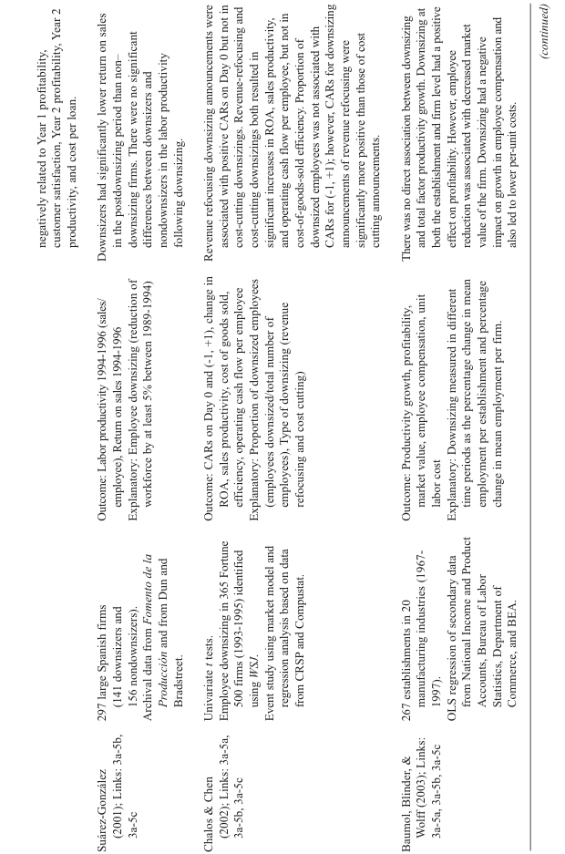

NOTE: figure/graphic rendered as an image from the PDF; its content is not machine-readable text. Caption (if any) follows as the next block.

**text found inside the figure**

Suárez-González

(2001); Links: 3a-5b,

3a-5c

Chalos & Chen

(2002); Links: 3a-5a,

3a-5b, 3a-5c

Baumol, Blinder, &

Wolff (2003); Links:

3a-5a, 3a-5b, 3a-5c

297 large Spanish firms (141 downsizers and

156 nondownsizers). Archival data from *Fomento de la*

*Producción* and from Dun and

Bradstreet.

Univariate *t* tests.

Employee downsizing in 365 Fortune

500 firms (1993-1995) identified using *WSJ*.

Event study using market model and

regression analysis based on data

from CRSP and Compustat.

267 establishments in 20 manufacturing industries (1967-

1997). OLS regression of secondary data

from National Income and Product

Accounts, Bureau of Labor

Statistics, Department of

Commerce, and BEA.

Outcome: Labor productivity 1994-1996 (sales/

employee), Return on sales 1994-1996

Explanatory: Employee downsizing (reduction of

workforce by at least 5% between 1989-1994)

Outcome: CARs on Day 0 and (-1, +1), change in

ROA, sales productivity, cost of goods sold,

efficiency, operating cash flow per employee

Explanatory: Proportion of downsized employees

(employees downsized/total number of

employees), Type of downsizing (revenue

refocusing and cost cutting)

Outcome: Productivity growth, profitability,

market value, employee compensation, unit

labor cost

Explanatory: Downsizing measured in different

time periods as the percentage change in mean

employment per establishment and percentage

change in mean employment per firm.

negatively related to Year 1 profitability,

customer satisfaction, Year 2 profitability, Year 2

productivity, and cost per loan.

Downsizers had significantly lower return on sales

in the postdownsizing period than non–

downsizing firms. There were no significant

differences between downsizers and

nondownsizers in the labor productivity

following downsizing.

Revenue refocusing downsizing announcements were

associated with positive CARs on Day 0 but not in

cost-cutting downsizings. Revenue-refocusing and

cost-cutting downsizings both resulted in

significant increases in ROA, sales productivity,

and operating cash flow per employee, but not in

cost-of-goods-sold efficiency. Proportion of

downsized employees was not associated with

CARs for (-1, +1); however, CARs for downsizing

announcements of revenue refocusing were

significantly more positive than those of cost

cutting announcements.

There was no direct association between downsizing

and total factor productivity growth. Downsizing at

both the establishment and firm level had a positive

effect on profitability. However, employee

reduction was associated with decreased market

value of the firm. Downsizing had a negative

impact on growth in employee compensation and

also led to lower per-unit costs.

*(continued)*

Page 50

330

**Table 4 (continued)**

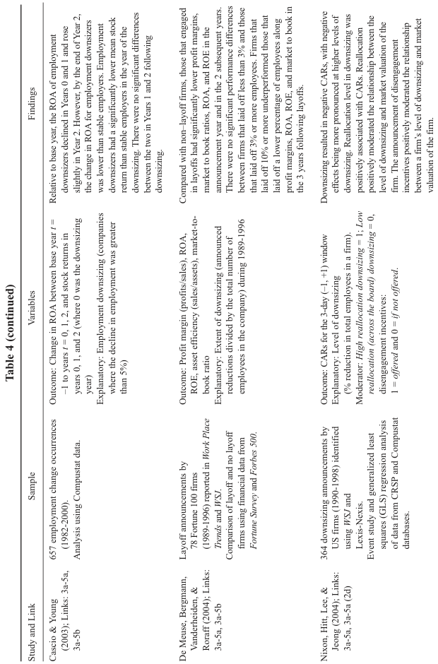

NOTE: figure/graphic rendered as an image from the PDF; its content is not machine-readable text. Caption (if any) follows as the next block.

**text found inside the figure**

Study and Link

Cascio & Young

(2003); Links: 3a-5a,

3a-5b

De Meuse, Bergmann,

Vanderheiden, &

Roraff (2004); Links:

3a-5a, 3a-5b

Nixon, Hitt, Lee, &

Jeong (2004); Links:

3a-5a, 3a-5a (2d)

Sample

657 employment change occurrences (1982-2000).

Analysis using Compustat data.

Layoff announcements by

78 Fortune 100 firms (1989-1996) reported in *Work Place*

*Trends* and *WSJ*.

Comparison of layoff and no layoff

firms using financial data from

*Fortune Survey* and *Forbes 500*.

364 downsizing announcements by US firms (1990-1998) identified

using *WSJ* and

Lexis-Nexis.

Event study and generalized least

squares (GLS) regression analysis

of data from CRSP and Compustat

databases.

Variables

Outcome: Change in ROA between base year *t* =

–1 to years *t* = 0, 1, 2, and stock returns in

years 0, 1, and 2 (where 0 was the downsizing

year)

Explanatory: Employment downsizing (companies

where the decline in employment was greater

than 5%)

Outcome: Profit margin (profits/sales), ROA,

ROE, asset efficiency (sales/assets), market-to-

book ratio

Explanatory: Extent of downsizing (announced

reductions divided by the total number of

employees in the company) during 1989-1996

Outcome: CARs for the 3-day (–1, +1) window

Explanatory: Level of downsizing

(% reduction in total employees in a firm).

Moderator: *High reallocation downsizing* = 1; *Low*

*reallocation (across the board) downsizing* = 0,

disengagement incentives:

1 = *offered* and 0 = *if not offered*.

Findings

Relative to base year, the ROA of employment

downsizers declined in Years 0 and 1 and rose

slightly in Year 2. However, by the end of Year 2,

the change in ROA for employment downsizers

was lower than stable employers. Employment

downsizers had a significantly lower mean stock

return than stable employers in the year of the

downsizing. There were no significant differences

between the two in Years 1 and 2 following

downsizing.

Compared with non–layoff firms, those that engaged

in layoffs had significantly lower profit margins,

market to book ratios, ROA, and ROE in the

announcement year and in the 2 subsequent years.

There were no significant performance differences

between firms that laid off less than 3% and those

that laid off 3% or more employees. Firms that

laid off 10% or more underperformed those that

laid off a lower percentage of employees along

profit margins, ROA, ROE, and market to book in

the 3 years following layoffs.

Downsizing resulted in negative CARs, with negative

effects being more pronounced at higher levels of

downsizing. Reallocation level in downsizing was

positively associated with CARs. Reallocation

positively moderated the relationship between the

level of downsizing and market valuation of the

firm. The announcement of disengagement

incentives positively moderated the relationship

between a firm’s level of downsizing and market

valuation of the firm.

Page 51

331

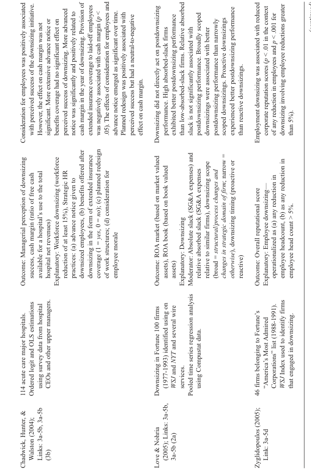

NOTE: figure/graphic rendered as an image from the PDF; its content is not machine-readable text. Caption (if any) follows as the next block.

**text found inside the figure**

Chadwick, Hunter, &

Walston (2004);

Links: 3a-5b, 3a-5b

(3b)

Love & Nohria

(2005); Links: 3a-5b,

3a-5b (2a)

Zyglidopoulos (2005);

Link: 3a-5d

114 acute care major hospitals. Ordered logit and OLS estimations

using survey data from hospital

CEOs and other upper managers.

Downsizing in Fortune 100 firms

(1977-1993) identified using on

*WSJ* and *NYT* and several wire

services.

Pooled time series regression analysis

using Compustat data.

46 firms belonging to Fortune’s “America’s Most Admired

Corporations” list (1988-1991).

*WSJ* Index used to identify firms

that engaged in downsizing.

Outcome: Managerial perception of downsizing

success, cash margin (ratio of free cash

available for a hospital’s use to the total

hospital net revenues)

Explanatory: Workforce downsizing (workforce

reduction of at least 15%), Strategic HR

practices: (a) advance notice given to

downsized employees, (b) benefits offered after

downsizing in the form of extended insurance

coverage (1 = *yes*, 0 = *no*); (c) planned redesign

of work structures; (d) consideration for

employee morale

Outcome: ROA market (based on market valued

assets), ROA book (based on book valued

assets)

Explanatory: Downsizing

Moderator: Absolute slack (SG&A expenses) and

relative absorbed slack (SG&A expenses

relative to similar firms), downsizing scope

(broad = *structural*/*process changes and*

*changes in strategic domain of firm*; narrow =

*otherwise*), downsizing timing (proactive or

reactive)

Outcome: Overall reputational score

Explanatory: Employee downsizing—

operationalized as (a) any reduction in

employee headcount, (b) as any reduction in

employee head count > 5%.

Consideration for employees was positively associated

with perceived success of the downsizing initiative.

However, the effect on cash margin was not

significant. More extensive advance notice or

benefits coverage had no significant effect on

perceived success of downsizing. More advanced

notice was significantly and positively related to

cash margin in the year of downsizing. Provision of

extended insurance coverage to laid-off employees

was negatively associated with cash margin (*p* <

.05). The effects of consideration for employees and

advance notice emerged as significant over time.

Planned redesign was positively associated with

perceived success but had a neutral-to-negative

effect on cash margin.

Downsizing did not directly act on postdownsizing

performance. High absorbed-slack firms

exhibited better postdownsizing performance

than low-absorbed-slack firms. Relative absorbed

slack is not significantly associated with

postdownsizing performance. Broadly scoped

downsizings were associated with better

postdownsizing performance than narrowly

scoped downsizings. Proactive downsizings

experienced better postdownsizing performance

than reactive downsizings.

Employment downsizing was associated with reduced

corporate reputation scores (*p* < .01 in the context

of any reduction in employees and *p* < .001 for

downsizing involving employee reductions greater

than 5%).

*(continued)*

Page 52

332

**Table 4 (continued)**

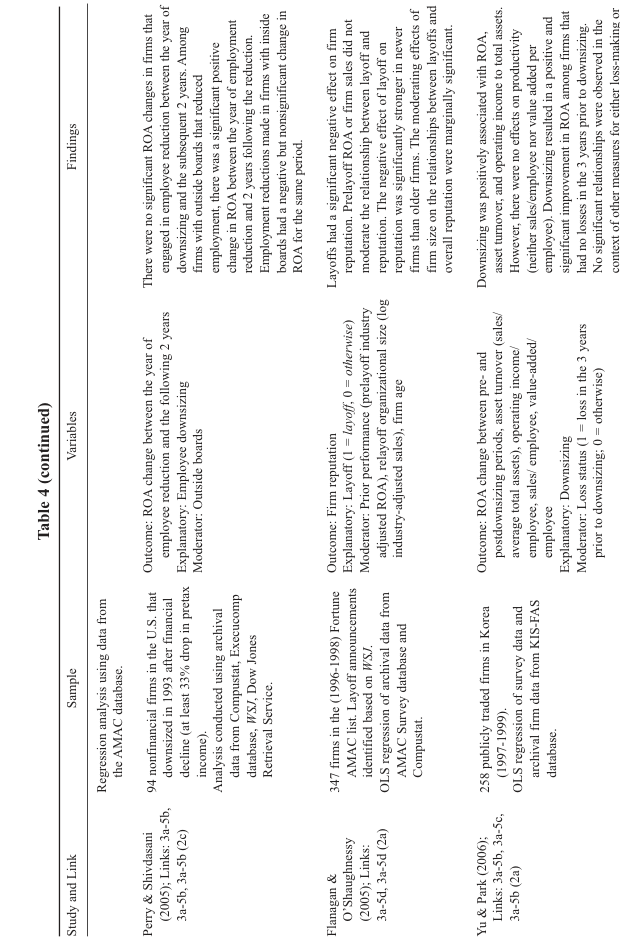

NOTE: figure/graphic rendered as an image from the PDF; its content is not machine-readable text. Caption (if any) follows as the next block.

**text found inside the figure**

Study and Link

Perry & Shivdasani

(2005); Links: 3a-5b,

3a-5b, 3a-5b (2c)

Flanagan &

O’Shaughnessy

(2005); Links:

3a-5d, 3a-5d (2a)

Yu & Park (2006);

Links: 3a-5b, 3a-5c,

3a-5b (2a)

Sample

Regression analysis using data from

the AMAC database.

94 nonfinancial firms in the U.S. that downsized in 1993 after financial

decline (at least 33% drop in pretax

income).

Analysis conducted using archival

data from Compustat, Execucomp

database, *WSJ*, Dow Jones

Retrieval Service.

347 firms in the (1996-1998) Fortune AMAC list. Layoff announcements

identified based on *WSJ*.

OLS regression of archival data from

AMAC Survey database and

Compustat.

258 publicly traded firms in Korea (1997-1999).

OLS regression of survey data and

archival firm data from KIS-FAS

database.

Variables

Outcome: ROA change between the year of

employee reduction and the following 2 years

Explanatory: Employee downsizing

Moderator: Outside boards

Outcome: Firm reputation

Explanatory: Layoff (1 = *layoff*, 0 = *otherwise*)

Moderator: Prior performance (prelayoff industry

adjusted ROA), relayoff organizational size (log

industry-adjusted sales), firm age

Outcome: ROA change between pre- and

postdownsizing periods, asset turnover (sales/

average total assets), operating income/

employee, sales/ employee, value-added/

employee

Explanatory: Downsizing

Moderator: Loss status (1 = loss in the 3 years

prior to downsizing; 0 = otherwise)

Findings

There were no significant ROA changes in firms that

engaged in employee reduction between the year of

downsizing and the subsequent 2 years. Among

firms with outside boards that reduced

employment, there was a significant positive

change in ROA between the year of employment

reduction and 2 years following the reduction.

Employment reductions made in firms with inside

boards had a negative but nonsignificant change in

ROA for the same period.

Layoffs had a significant negative effect on firm

reputation. Prelayoff ROA or firm sales did not

moderate the relationship between layoff and

reputation. The negative effect of layoff on

reputation was significantly stronger in newer

firms than older firms. The moderating effects of

firm size on the relationships between layoffs and

overall reputation were marginally significant.

Downsizing was positively associated with ROA,

asset turnover, and operating income to total assets.

However, there were no effects on productivity

(neither sales/employee nor value added per

employee). Downsizing resulted in a positive and

significant improvement in ROA among firms that

had no losses in the 3 years prior to downsizing.

No significant relationships were observed in the

context of other measures for either loss-making or

non–loss making firms.

Page 53

333

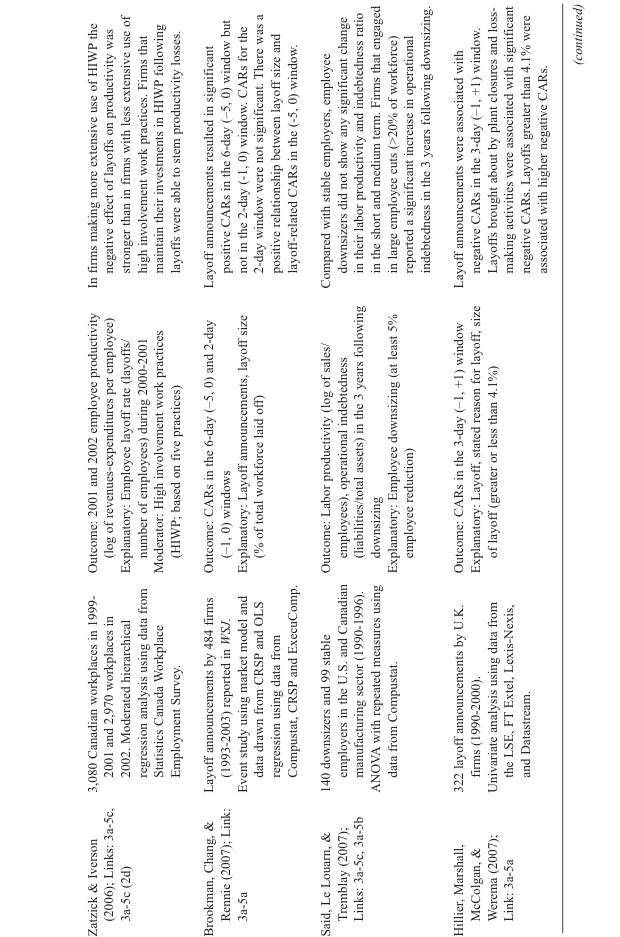

NOTE: figure/graphic rendered as an image from the PDF; its content is not machine-readable text. Caption (if any) follows as the next block.

**text found inside the figure**

Zatzick & Iverson

(2006); Links: 3a-5c,

3a-5c (2d)

Brookman, Chang, &

Rennie (2007); Link:

3a-5a

Said, Le Louarn, &

Tremblay (2007);

Links: 3a-5c, 3a-5b

Hillier, Marshall,

McColgan, &

Werema (2007);

Link: 3a-5a

3,080 Canadian workplaces in 1999- 2001 and 2,970 workplaces in 2002. Moderated hierarchical regression analysis using data from

Statistics Canada Workplace

Employment Survey.

Layoff announcements by 484 firms

(1993-2003) reported in *WSJ*.

Event study using market model and

data drawn from CRSP and OLS

regression using data from

Compustat, CRSP and ExecuComp.

140 downsizers and 99 stable employers in the U.S. and Canadian

manufacturing sector (1990-1996).

ANOVA with repeated measures using

data from Compustat.

322 layoff announcements by U.K. firms (1990-2000).

Univariate analysis using data from

the LSE, FT Extel, Lexis-Nexis,

and Datastream.

Outcome: 2001 and 2002 employee productivity

(log of revenues-expenditures per employee)

Explanatory: Employee layoff rate (layoffs/

number of employees) during 2000-2001

Moderator: High involvement work practices

(HIWP; based on five practices)

Outcome: CARs in the 6-day (–5, 0) and 2-day

(–1, 0) windows

Explanatory: Layoff announcements, layoff size

(% of total workforce laid off)

Outcome: Labor productivity (log of sales/

employees), operational indebtedness

(liabilities/total assets) in the 3 years following

downsizing

Explanatory: Employee downsizing (at least 5%

employee reduction)

Outcome: CARs in the 3-day (–1, +1) window

Explanatory: Layoff, stated reason for layoff, size

of layoff (greater or less than 4.1%)

In firms making more extensive use of HIWP the

negative effect of layoffs on productivity was

stronger than in firms with less extensive use of

high involvement work practices. Firms that

maintain their investments in HIWP following

layoffs were able to stem productivity losses.

Layoff announcements resulted in significant

positive CARs in the 6-day (–5, 0) window but

not in the 2-day (-1, 0) window. CARs for the

2-day window were not significant. There was a positive relationship between layoff size and

layoff-related CARs in the (-5, 0) window.

Compared with stable employers, employee

downsizers did not show any significant change

in their labor productivity and indebtedness ratio

in the short and medium term. Firms that engaged

in large employee cuts (>20% of workforce)

reported a significant increase in operational

indebtedness in the 3 years following downsizing.

Layoff announcements were associated with

negative CARs in the 3-day (–1, +1) window.

Layoffs brought about by plant closures and loss-

making activities were associated with significant

negative CARs. Layoffs greater than 4.1% were

associated with higher negative CARs.

*(continued)*

Page 54

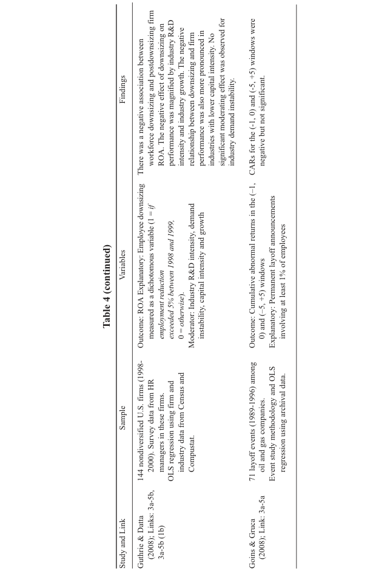

NOTE: figure/graphic rendered as an image from the PDF; its content is not machine-readable text. Caption (if any) follows as the next block.

334

**Table 4 (continued)**

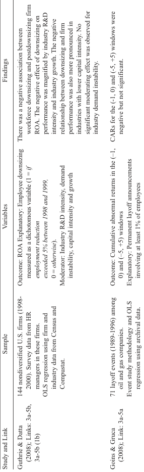

NOTE: complex table shown as an image of the PDF; the text below is a rough machine extraction and may be mis-aligned.

**extracted text (unreliable layout)**

Page 55

Datta et al. / Causes and Effects of Employee Downsizing 335

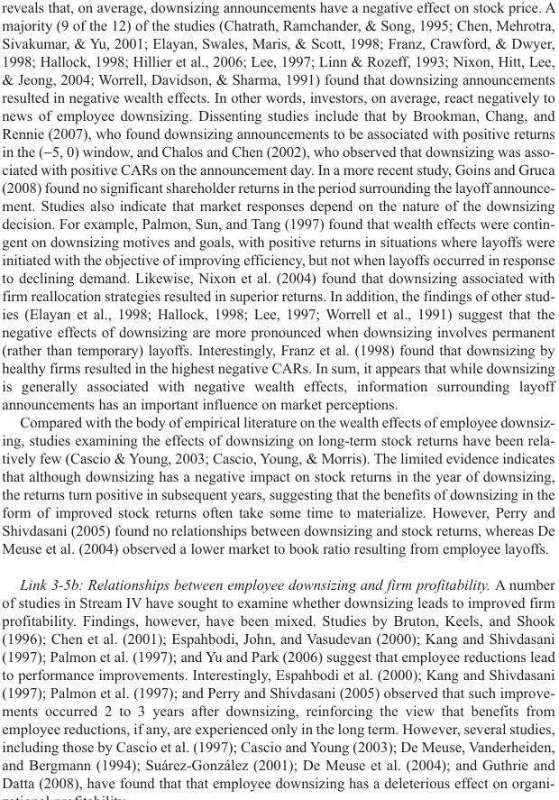

NOTE: figure/graphic rendered as an image from the PDF; its content is not machine-readable text. Caption (if any) follows as the next block.

**text found inside the figure**

Compared with the body of empirical literature on the wealth effects of employee downsizing, studies examining the effects of downsizing on long-term stock returns have been relatively few (Cascio & Young, 2003; Cascio, Young, & Morris). The limited evidence indicates that although downsizing has a negative impact on stock returns in the year of downsizing, the returns turn positive in subsequent years, suggesting that the benefits of downsizing in the form of improved stock returns often take some time to materialize. However, Perry and Shivdasani (2005) found no relationships between downsizing and stock returns, whereas De Meuse et al. (2004) observed a lower market to book ratio resulting from employee layoffs.

*Link 3-5b: Relationships between employee downsizing and firm profitability.* A number of studies in Stream IV have sought to examine whether downsizing leads to improved firm profitability. Findings, however, have been mixed. Studies by Bruton, Keels, and Shook (1996); Chen et al. (2001); Espahbodi, John, and Vasudevan (2000); Kang and Shivdasani (1997); Palmon et al. (1997); and Yu and Park (2006) suggest that employee reductions lead to performance improvements. Interestingly, Espahbodi et al. (2000); Kang and Shivdasani (1997); Palmon et al. (1997); and Perry and Shivdasani (2005) observed that such improvements occurred 2 to 3 years after downsizing, reinforcing the view that benefits from employee reductions, if any, are experienced only in the long term. However, several studies, including those by Cascio et al. (1997); Cascio and Young (2003); De Meuse, Vanderheiden, and Bergmann (1994); Suárez-González (2001); De Meuse et al. (2004); and Guthrie and Datta (2008), have found that that employee downsizing has a deleterious effect on organizational profitability.

Page 56

336 Journal of Management / January 2010

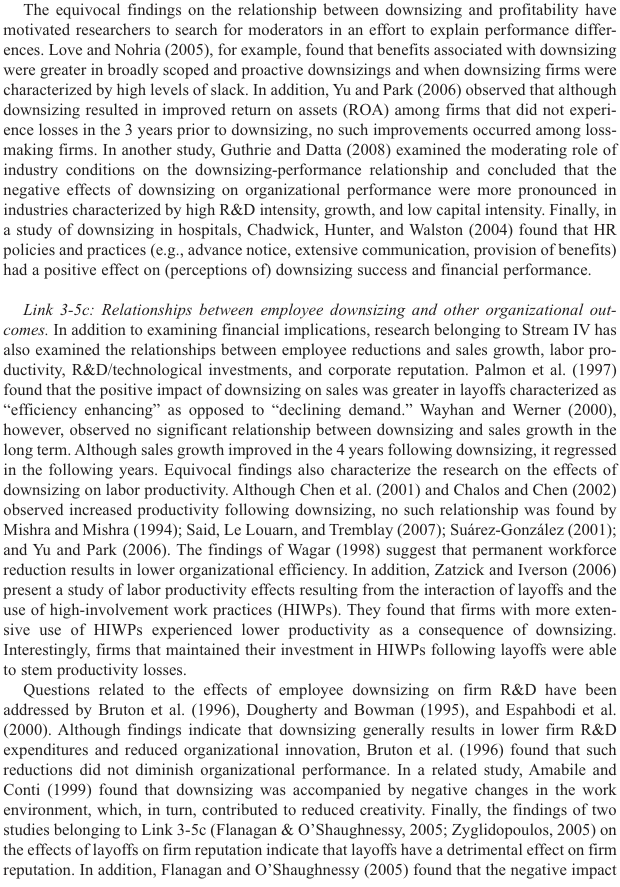

NOTE: figure/graphic rendered as an image from the PDF; its content is not machine-readable text. Caption (if any) follows as the next block.

**text found inside the figure**

The equivocal findings on the relationship between downsizing and profitability have motivated researchers to search for moderators in an effort to explain performance differences. Love and Nohria (2005), for example, found that benefits associated with downsizing were greater in broadly scoped and proactive downsizings and when downsizing firms were characterized by high levels of slack. In addition, Yu and Park (2006) observed that although downsizing resulted in improved return on assets (ROA) among firms that did not experience losses in the 3 years prior to downsizing, no such improvements occurred among lossmaking firms. In another study, Guthrie and Datta (2008) examined the moderating role of industry conditions on the downsizing-performance relationship and concluded that the negative effects of downsizing on organizational performance were more pronounced in industries characterized by high R&D intensity, growth, and low capital intensity. Finally, in a study of downsizing in hospitals, Chadwick, Hunter, and Walston (2004) found that HR policies and practices (e.g., advance notice, extensive communication, provision of benefits) had a positive effect on (perceptions of) downsizing success and financial performance.

*Link 3-5c: Relationships between employee downsizing and other organizational outcomes.* In addition to examining financial implications, research belonging to Stream IV has also examined the relationships between employee reductions and sales growth, labor productivity, R&D/technological investments, and corporate reputation. Palmon et al. (1997) found that the positive impact of downsizing on sales was greater in layoffs characterized as “efficiency enhancing” as opposed to “declining demand.” Wayhan and Werner (2000), however, observed no significant relationship between downsizing and sales growth in the long term. Although sales growth improved in the 4 years following downsizing, it regressed in the following years. Equivocal findings also characterize the research on the effects of downsizing on labor productivity. Although Chen et al. (2001) and Chalos and Chen (2002) observed increased productivity following downsizing, no such relationship was found by Mishra and Mishra (1994); Said, Le Louarn, and Tremblay (2007); Suárez-González (2001); and Yu and Park (2006). The findings of Wagar (1998) suggest that permanent workforce reduction results in lower organizational efficiency. In addition, Zatzick and Iverson (2006) present a study of labor productivity effects resulting from the interaction of layoffs and the use of high-involvement work practices (HIWPs). They found that firms with more extensive use of HIWPs experienced lower productivity as a consequence of downsizing. Interestingly, firms that maintained their investment in HIWPs following layoffs were able to stem productivity losses.

Questions related to the effects of employee downsizing on firm R&D have been addressed by Bruton et al. (1996), Dougherty and Bowman (1995), and Espahbodi et al. (2000). Although findings indicate that downsizing generally results in lower firm R&D expenditures and reduced organizational innovation, Bruton et al. (1996) found that such reductions did not diminish organizational performance. In a related study, Amabile and Conti (1999) found that downsizing was accompanied by negative changes in the work environment, which, in turn, contributed to reduced creativity. Finally, the findings of two studies belonging to Link 3-5c (Flanagan & O’Shaughnessy, 2005; Zyglidopoulos, 2005) on the effects of layoffs on firm reputation indicate that layoffs have a detrimental effect on firm reputation. In addition, Flanagan and O’Shaughnessy (2005) found that the negative impact

Page 57

Datta et al. / Causes and Effects of Employee Downsizing 337

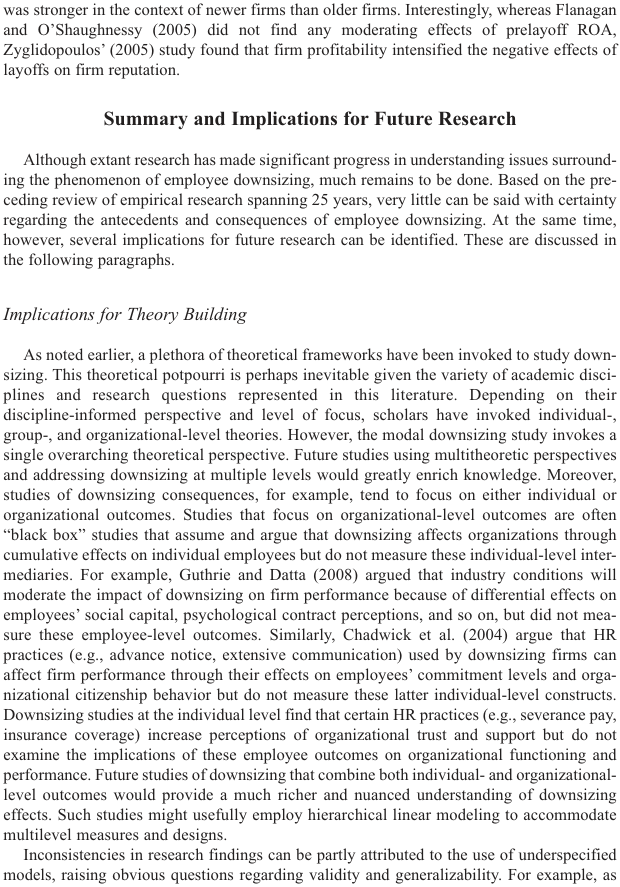

NOTE: figure/graphic rendered as an image from the PDF; its content is not machine-readable text. Caption (if any) follows as the next block.

**text found inside the figure**

was stronger in the context of newer firms than older firms. Interestingly, whereas Flanagan and O’Shaughnessy (2005) did not find any moderating effects of prelayoff ROA, Zyglidopoulos’ (2005) study found that firm profitability intensified the negative effects of layoffs on firm reputation.

**Summary and Implications for Future Research**

Although extant research has made significant progress in understanding issues surrounding the phenomenon of employee downsizing, much remains to be done. Based on the preceding review of empirical research spanning 25 years, very little can be said with certainty regarding the antecedents and consequences of employee downsizing. At the same time, however, several implications for future research can be identified. These are discussed in the following paragraphs.

*Implications for Theory Building*

As noted earlier, a plethora of theoretical frameworks have been invoked to study downsizing. This theoretical potpourri is perhaps inevitable given the variety of academic disciplines and research questions represented in this literature. Depending on their discipline-informed perspective and level of focus, scholars have invoked individual-, group-, and organizational-level theories. However, the modal downsizing study invokes a single overarching theoretical perspective. Future studies using multitheoretic perspectives and addressing downsizing at multiple levels would greatly enrich knowledge. Moreover, studies of downsizing consequences, for example, tend to focus on either individual or organizational outcomes. Studies that focus on organizational-level outcomes are often “black box” studies that assume and argue that downsizing affects organizations through cumulative effects on individual employees but do not measure these individual-level intermediaries. For example, Guthrie and Datta (2008) argued that industry conditions will moderate the impact of downsizing on firm performance because of differential effects on employees’ social capital, psychological contract perceptions, and so on, but did not measure these employee-level outcomes. Similarly, Chadwick et al. (2004) argue that HR practices (e.g., advance notice, extensive communication) used by downsizing firms can affect firm performance through their effects on employees’ commitment levels and organizational citizenship behavior but do not measure these latter individual-level constructs. Downsizing studies at the individual level find that certain HR practices (e.g., severance pay, insurance coverage) increase perceptions of organizational trust and support but do not examine the implications of these employee outcomes on organizational functioning and performance. Future studies of downsizing that combine both individual- and organizationallevel outcomes would provide a much richer and nuanced understanding of downsizing effects. Such studies might usefully employ hierarchical linear modeling to accommodate multilevel measures and designs.

Inconsistencies in research findings can be partly attributed to the use of underspecified models, raising obvious questions regarding validity and generalizability. For example, as

Page 58

338 Journal of Management / January 2010

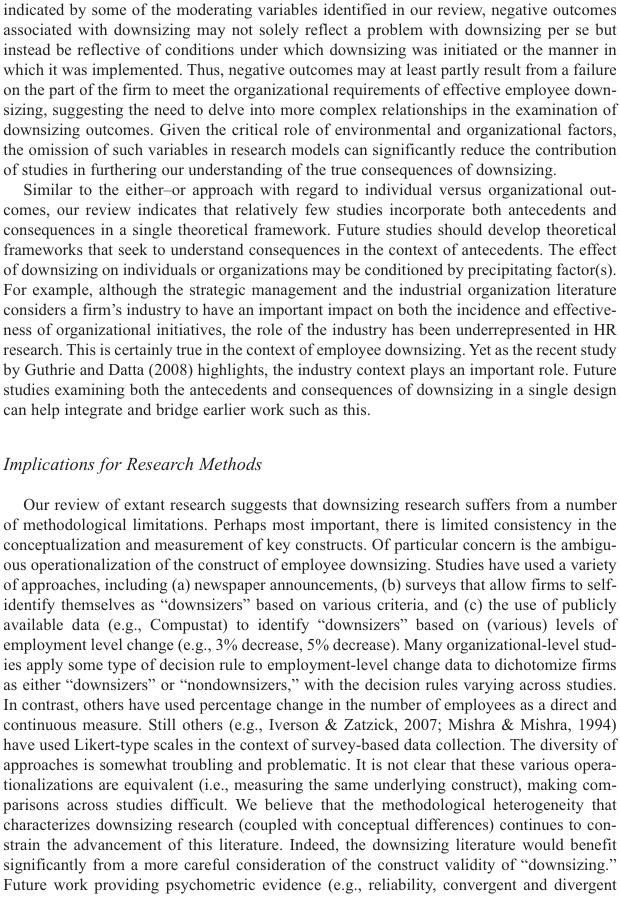

NOTE: figure/graphic rendered as an image from the PDF; its content is not machine-readable text. Caption (if any) follows as the next block.

**text found inside the figure**

indicated by some of the moderating variables identified in our review, negative outcomes associated with downsizing may not solely reflect a problem with downsizing per se but instead be reflective of conditions under which downsizing was initiated or the manner in which it was implemented. Thus, negative outcomes may at least partly result from a failure on the part of the firm to meet the organizational requirements of effective employee downsizing, suggesting the need to delve into more complex relationships in the examination of downsizing outcomes. Given the critical role of environmental and organizational factors, the omission of such variables in research models can significantly reduce the contribution of studies in furthering our understanding of the true consequences of downsizing.

Similar to the either–or approach with regard to individual versus organizational outcomes, our review indicates that relatively few studies incorporate both antecedents and consequences in a single theoretical framework. Future studies should develop theoretical frameworks that seek to understand consequences in the context of antecedents. The effect of downsizing on individuals or organizations may be conditioned by precipitating factor(s). For example, although the strategic management and the industrial organization literature considers a firm’s industry to have an important impact on both the incidence and effectiveness of organizational initiatives, the role of the industry has been underrepresented in HR research. This is certainly true in the context of employee downsizing. Yet as the recent study by Guthrie and Datta (2008) highlights, the industry context plays an important role. Future studies examining both the antecedents and consequences of downsizing in a single design can help integrate and bridge earlier work such as this.

*Implications for Research Methods*

Our review of extant research suggests that downsizing research suffers from a number of methodological limitations. Perhaps most important, there is limited consistency in the conceptualization and measurement of key constructs. Of particular concern is the ambiguous operationalization of the construct of employee downsizing. Studies have used a variety of approaches, including (a) newspaper announcements, (b) surveys that allow firms to selfidentify themselves as “downsizers” based on various criteria, and (c) the use of publicly available data (e.g., Compustat) to identify “downsizers” based on (various) levels of employment level change (e.g., 3% decrease, 5% decrease). Many organizational-level studies apply some type of decision rule to employment-level change data to dichotomize firms as either “downsizers” or “nondownsizers,” with the decision rules varying across studies. In contrast, others have used percentage change in the number of employees as a direct and continuous measure. Still others (e.g., Iverson & Zatzick, 2007; Mishra & Mishra, 1994) have used Likert-type scales in the context of survey-based data collection. The diversity of approaches is somewhat troubling and problematic. It is not clear that these various operationalizations are equivalent (i.e., measuring the same underlying construct), making comparisons across studies difficult. We believe that the methodological heterogeneity that characterizes downsizing research (coupled with conceptual differences) continues to constrain the advancement of this literature. Indeed, the downsizing literature would benefit significantly from a more careful consideration of the construct validity of “downsizing.” Future work providing psychometric evidence (e.g., reliability, convergent and divergent

Page 59

Datta et al. / Causes and Effects of Employee Downsizing 339

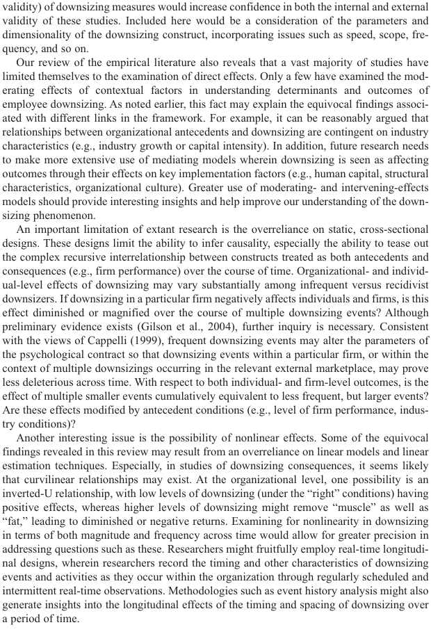

NOTE: figure/graphic rendered as an image from the PDF; its content is not machine-readable text. Caption (if any) follows as the next block.

**text found inside the figure**

validity) of downsizing measures would increase confidence in both the internal and external validity of these studies. Included here would be a consideration of the parameters and dimensionality of the downsizing construct, incorporating issues such as speed, scope, frequency, and so on.

Our review of the empirical literature also reveals that a vast majority of studies have limited themselves to the examination of direct effects. Only a few have examined the moderating effects of contextual factors in understanding determinants and outcomes of employee downsizing. As noted earlier, this fact may explain the equivocal findings associated with different links in the framework. For example, it can be reasonably argued that relationships between organizational antecedents and downsizing are contingent on industry characteristics (e.g., industry growth or capital intensity). In addition, future research needs to make more extensive use of mediating models wherein downsizing is seen as affecting outcomes through their effects on key implementation factors (e.g., human capital, structural characteristics, organizational culture). Greater use of moderating- and intervening-effects models should provide interesting insights and help improve our understanding of the downsizing phenomenon.

An important limitation of extant research is the overreliance on static, cross-sectional designs. These designs limit the ability to infer causality, especially the ability to tease out the complex recursive interrelationship between constructs treated as both antecedents and consequences (e.g., firm performance) over the course of time. Organizational- and individual-level effects of downsizing may vary substantially among infrequent versus recidivist downsizers. If downsizing in a particular firm negatively affects individuals and firms, is this effect diminished or magnified over the course of multiple downsizing events? Although preliminary evidence exists (Gilson et al., 2004), further inquiry is necessary. Consistent with the views of Cappelli (1999), frequent downsizing events may alter the parameters of the psychological contract so that downsizing events within a particular firm, or within the context of multiple downsizings occurring in the relevant external marketplace, may prove less deleterious across time. With respect to both individual- and firm-level outcomes, is the effect of multiple smaller events cumulatively equivalent to less frequent, but larger events? Are these effects modified by antecedent conditions (e.g., level of firm performance, industry conditions)?

Another interesting issue is the possibility of nonlinear effects. Some of the equivocal findings revealed in this review may result from an overreliance on linear models and linear estimation techniques. Especially, in studies of downsizing consequences, it seems likely that curvilinear relationships may exist. At the organizational level, one possibility is an inverted-U relationship, with low levels of downsizing (under the “right” conditions) having positive effects, whereas higher levels of downsizing might remove “muscle” as well as “fat,” leading to diminished or negative returns. Examining for nonlinearity in downsizing in terms of both magnitude and frequency across time would allow for greater precision in addressing questions such as these. Researchers might fruitfully employ real-time longitudinal designs, wherein researchers record the timing and other characteristics of downsizing events and activities as they occur within the organization through regularly scheduled and intermittent real-time observations. Methodologies such as event history analysis might also generate insights into the longitudinal effects of the timing and spacing of downsizing over a period of time.

Page 60

340 Journal of Management / January 2010

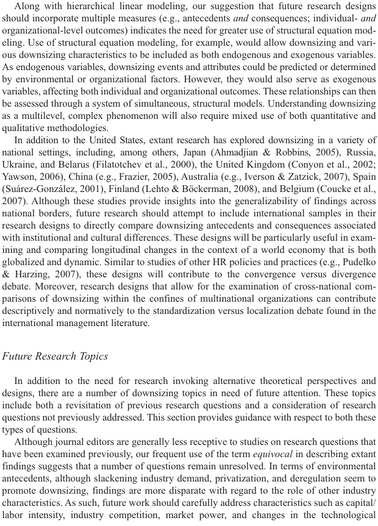

NOTE: figure/graphic rendered as an image from the PDF; its content is not machine-readable text. Caption (if any) follows as the next block.

**text found inside the figure**

Along with hierarchical linear modeling, our suggestion that future research designs should incorporate multiple measures (e.g., antecedents *and* consequences; individual- *and* organizational-level outcomes) indicates the need for greater use of structural equation modeling. Use of structural equation modeling, for example, would allow downsizing and various downsizing characteristics to be included as both endogenous and exogenous variables. As endogenous variables, downsizing events and attributes could be predicted or determined by environmental or organizational factors. However, they would also serve as exogenous variables, affecting both individual and organizational outcomes. These relationships can then be assessed through a system of simultaneous, structural models. Understanding downsizing as a multilevel, complex phenomenon will also require mixed use of both quantitative and qualitative methodologies.

In addition to the United States, extant research has explored downsizing in a variety of national settings, including, among others, Japan (Ahmadjian & Robbins, 2005), Russia, Ukraine, and Belarus (Filatotchev et al., 2000), the United Kingdom (Conyon et al., 2002; Yawson, 2006), China (e.g., Frazier, 2005), Australia (e.g., Iverson & Zatzick, 2007), Spain (Suárez-González, 2001), Finland (Lehto & Böckerman, 2008), and Belgium (Coucke et al., 2007). Although these studies provide insights into the generalizability of findings across national borders, future research should attempt to include international samples in their research designs to directly compare downsizing antecedents and consequences associated with institutional and cultural differences. These designs will be particularly useful in examining and comparing longitudinal changes in the context of a world economy that is both globalized and dynamic. Similar to studies of other HR policies and practices (e.g., Pudelko & Harzing, 2007), these designs will contribute to the convergence versus divergence debate. Moreover, research designs that allow for the examination of cross-national comparisons of downsizing within the confines of multinational organizations can contribute descriptively and normatively to the standardization versus localization debate found in the international management literature.

*Future Research Topics*

In addition to the need for research invoking alternative theoretical perspectives and designs, there are a number of downsizing topics in need of future attention. These topics include both a revisitation of previous research questions and a consideration of research questions not previously addressed. This section provides guidance with respect to both these types of questions.

Although journal editors are generally less receptive to studies on research questions that have been examined previously, our frequent use of the term *equivocal* in describing extant findings suggests that a number of questions remain unresolved. In terms of environmental antecedents, although slackening industry demand, privatization, and deregulation seem to promote downsizing, findings are more disparate with regard to the role of other industry characteristics. As such, future work should carefully address characteristics such as capital/ labor intensity, industry competition, market power, and changes in the technological

Page 61

Datta et al. / Causes and Effects of Employee Downsizing 341

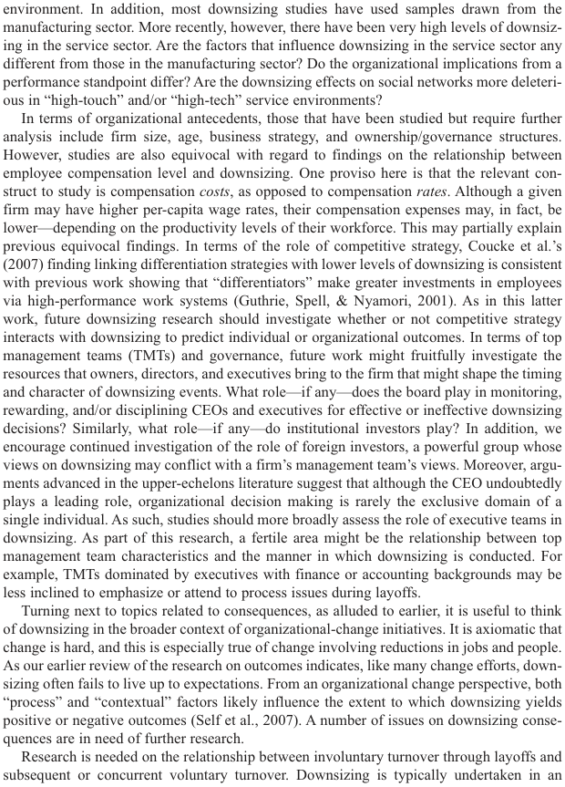

NOTE: figure/graphic rendered as an image from the PDF; its content is not machine-readable text. Caption (if any) follows as the next block.

**text found inside the figure**

environment. In addition, most downsizing studies have used samples drawn from the manufacturing sector. More recently, however, there have been very high levels of downsizing in the service sector. Are the factors that influence downsizing in the service sector any different from those in the manufacturing sector? Do the organizational implications from a performance standpoint differ? Are the downsizing effects on social networks more deleterious in “high-touch” and/or “high-tech” service environments?

In terms of organizational antecedents, those that have been studied but require further analysis include firm size, age, business strategy, and ownership/governance structures. However, studies are also equivocal with regard to findings on the relationship between employee compensation level and downsizing. One proviso here is that the relevant construct to study is compensation *costs*, as opposed to compensation *rates*. Although a given firm may have higher per-capita wage rates, their compensation expenses may, in fact, be lower—depending on the productivity levels of their workforce. This may partially explain previous equivocal findings. In terms of the role of competitive strategy, Coucke et al.’s (2007) finding linking differentiation strategies with lower levels of downsizing is consistent with previous work showing that “differentiators” make greater investments in employees via high-performance work systems (Guthrie, Spell, & Nyamori, 2001). As in this latter work, future downsizing research should investigate whether or not competitive strategy interacts with downsizing to predict individual or organizational outcomes. In terms of top management teams (TMTs) and governance, future work might fruitfully investigate the resources that owners, directors, and executives bring to the firm that might shape the timing and character of downsizing events. What role—if any—does the board play in monitoring, rewarding, and/or disciplining CEOs and executives for effective or ineffective downsizing decisions? Similarly, what role—if any—do institutional investors play? In addition, we encourage continued investigation of the role of foreign investors, a powerful group whose views on downsizing may conflict with a firm’s management team’s views. Moreover, arguments advanced in the upper-echelons literature suggest that although the CEO undoubtedly plays a leading role, organizational decision making is rarely the exclusive domain of a single individual. As such, studies should more broadly assess the role of executive teams in downsizing. As part of this research, a fertile area might be the relationship between top management team characteristics and the manner in which downsizing is conducted. For example, TMTs dominated by executives with finance or accounting backgrounds may be less inclined to emphasize or attend to process issues during layoffs.

Turning next to topics related to consequences, as alluded to earlier, it is useful to think of downsizing in the broader context of organizational-change initiatives. It is axiomatic that change is hard, and this is especially true of change involving reductions in jobs and people. As our earlier review of the research on outcomes indicates, like many change efforts, downsizing often fails to live up to expectations. From an organizational change perspective, both “process” and “contextual” factors likely influence the extent to which downsizing yields positive or negative outcomes (Self et al., 2007). A number of issues on downsizing consequences are in need of further research.

Research is needed on the relationship between involuntary turnover through layoffs and subsequent or concurrent voluntary turnover. Downsizing is typically undertaken in an

Page 62

342 Journal of Management / January 2010

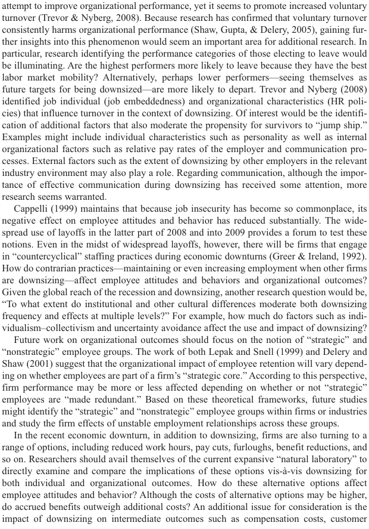

NOTE: figure/graphic rendered as an image from the PDF; its content is not machine-readable text. Caption (if any) follows as the next block.

**text found inside the figure**

attempt to improve organizational performance, yet it seems to promote increased voluntary turnover (Trevor & Nyberg, 2008). Because research has confirmed that voluntary turnover consistently harms organizational performance (Shaw, Gupta, & Delery, 2005), gaining further insights into this phenomenon would seem an important area for additional research. In particular, research identifying the performance categories of those electing to leave would be illuminating. Are the highest performers more likely to leave because they have the best labor market mobility? Alternatively, perhaps lower performers—seeing themselves as future targets for being downsized—are more likely to depart. Trevor and Nyberg (2008) identified job individual (job embeddedness) and organizational characteristics (HR policies) that influence turnover in the context of downsizing. Of interest would be the identification of additional factors that also moderate the propensity for survivors to “jump ship.” Examples might include individual characteristics such as personality as well as internal organizational factors such as relative pay rates of the employer and communication processes. External factors such as the extent of downsizing by other employers in the relevant industry environment may also play a role. Regarding communication, although the importance of effective communication during downsizing has received some attention, more research seems warranted.

Cappelli (1999) maintains that because job insecurity has become so commonplace, its negative effect on employee attitudes and behavior has reduced substantially. The widespread use of layoffs in the latter part of 2008 and into 2009 provides a forum to test these notions. Even in the midst of widespread layoffs, however, there will be firms that engage in “countercyclical” staffing practices during economic downturns (Greer & Ireland, 1992). How do contrarian practices—maintaining or even increasing employment when other firms are downsizing—affect employee attitudes and behaviors and organizational outcomes? Given the global reach of the recession and downsizing, another research question would be, “To what extent do institutional and other cultural differences moderate both downsizing frequency and effects at multiple levels?” For example, how much do factors such as individualism–collectivism and uncertainty avoidance affect the use and impact of downsizing?

Future work on organizational outcomes should focus on the notion of “strategic” and “nonstrategic” employee groups. The work of both Lepak and Snell (1999) and Delery and Shaw (2001) suggest that the organizational impact of employee retention will vary depending on whether employees are part of a firm’s “strategic core.” According to this perspective, firm performance may be more or less affected depending on whether or not “strategic” employees are “made redundant.” Based on these theoretical frameworks, future studies might identify the “strategic” and “nonstrategic” employee groups within firms or industries and study the firm effects of unstable employment relationships across these groups.

In the recent economic downturn, in addition to downsizing, firms are also turning to a range of options, including reduced work hours, pay cuts, furloughs, benefit reductions, and so on. Researchers should avail themselves of the current expansive “natural laboratory” to directly examine and compare the implications of these options vis-à-vis downsizing for both individual and organizational outcomes. How do these alternative options affect employee attitudes and behavior? Although the costs of alternative options may be higher, do accrued benefits outweigh additional costs? An additional issue for consideration is the impact of downsizing on intermediate outcomes such as compensation costs, customer

Page 63

Datta et al. / Causes and Effects of Employee Downsizing 343

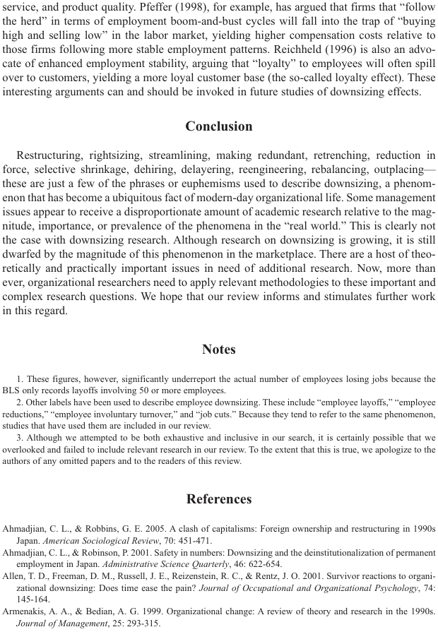

NOTE: figure/graphic rendered as an image from the PDF; its content is not machine-readable text. Caption (if any) follows as the next block.

**text found inside the figure**

service, and product quality. Pfeffer (1998), for example, has argued that firms that “follow the herd” in terms of employment boom-and-bust cycles will fall into the trap of “buying high and selling low” in the labor market, yielding higher compensation costs relative to those firms following more stable employment patterns. Reichheld (1996) is also an advocate of enhanced employment stability, arguing that “loyalty” to employees will often spill over to customers, yielding a more loyal customer base (the so-called loyalty effect). These interesting arguments can and should be invoked in future studies of downsizing effects.

**Conclusion**

Restructuring, rightsizing, streamlining, making redundant, retrenching, reduction in force, selective shrinkage, dehiring, delayering, reengineering, rebalancing, outplacing— these are just a few of the phrases or euphemisms used to describe downsizing, a phenomenon that has become a ubiquitous fact of modern-day organizational life. Some management issues appear to receive a disproportionate amount of academic research relative to the magnitude, importance, or prevalence of the phenomena in the “real world.” This is clearly not the case with downsizing research. Although research on downsizing is growing, it is still dwarfed by the magnitude of this phenomenon in the marketplace. There are a host of theoretically and practically important issues in need of additional research. Now, more than ever, organizational researchers need to apply relevant methodologies to these important and complex research questions. We hope that our review informs and stimulates further work in this regard.

**Notes**

1. These figures, however, significantly underreport the actual number of employees losing jobs because the BLS only records layoffs involving 50 or more employees.

2. Other labels have been used to describe employee downsizing. These include “employee layoffs,” “employee reductions,” “employee involuntary turnover,” and “job cuts.” Because they tend to refer to the same phenomenon, studies that have used them are included in our review.

3. Although we attempted to be both exhaustive and inclusive in our search, it is certainly possible that we overlooked and failed to include relevant research in our review. To the extent that this is true, we apologize to the authors of any omitted papers and to the readers of this review.

**References**

Ahmadjian, C. L., & Robbins, G. E. 2005. A clash of capitalisms: Foreign ownership and restructuring in 1990s

Japan. *American Sociological Review*, 70: 451-471. Ahmadjian, C. L., & Robinson, P. 2001. Safety in numbers: Downsizing and the deinstitutionalization of permanent

employment in Japan. *Administrative Science Quarterly*, 46: 622-654. Allen, T. D., Freeman, D. M., Russell, J. E., Reizenstein, R. C., & Rentz, J. O. 2001. Survivor reactions to organi-

zational downsizing: Does time ease the pain? *Journal of Occupational and Organizational Psychology*, 74: 145-164. Armenakis, A. A., & Bedian, A. G. 1999. Organizational change: A review of theory and research in the 1990s.

*Journal of Management*, 25: 293-315.

Page 64

344 Journal of Management / January 2010

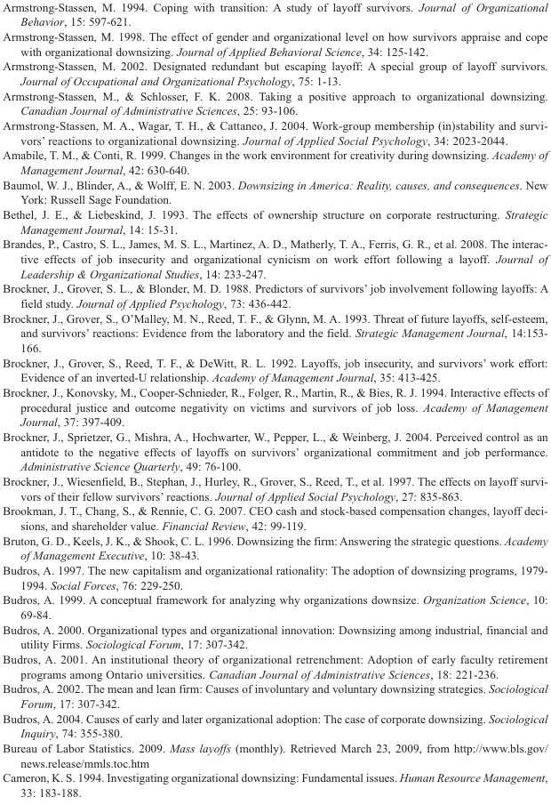

NOTE: figure/graphic rendered as an image from the PDF; its content is not machine-readable text. Caption (if any) follows as the next block.

**text found inside the figure**

Armstrong-Stassen, M. 1994. Coping with transition: A study of layoff survivors. *Journal of Organizational*

*Behavior*, 15: 597-621. Armstrong-Stassen, M. 1998. The effect of gender and organizational level on how survivors appraise and cope

with organizational downsizing. *Journal of Applied Behavioral Science*, 34: 125-142. Armstrong-Stassen, M. 2002. Designated redundant but escaping layoff: A special group of layoff survivors.

*Journal of Occupational and Organizational Psychology*, 75: 1-13. Armstrong-Stassen, M., & Schlosser, F. K. 2008. Taking a positive approach to organizational downsizing.

*Canadian Journal of Administrative Sciences*, 25: 93-106. Armstrong-Stassen, M. A., Wagar, T. H., & Cattaneo, J. 2004. Work-group membership (in)stability and survi-

vors’ reactions to organizational downsizing. *Journal of Applied Social Psychology*, 34: 2023-2044. Amabile, T. M., & Conti, R. 1999. Changes in the work environment for creativity during downsizing. *Academy of*

*Management Journal*, 42: 630-640. Baumol, W. J., Blinder, A., & Wolff, E. N. 2003. *Downsizing in America: Reality, causes, and consequences*. New

York: Russell Sage Foundation. Bethel, J. E., & Liebeskind, J. 1993. The effects of ownership structure on corporate restructuring. *Strategic*

*Management Journal*, 14: 15-31. Brandes, P., Castro, S. L., James, M. S. L., Martinez, A. D., Matherly, T. A., Ferris, G. R., et al. 2008. The interac-

tive effects of job insecurity and organizational cynicism on work effort following a layoff. *Journal of Leadership & Organizational Studies*, 14: 233-247. Brockner, J., Grover, S. L., & Blonder, M. D. 1988. Predictors of survivors’ job involvement following layoffs: A

field study. *Journal of Applied Psychology*, 73: 436-442. Brockner, J., Grover, S., O’Malley, M. N., Reed, T. F., & Glynn, M. A. 1993. Threat of future layoffs, self-esteem,

and survivors’ reactions: Evidence from the laboratory and the field. *Strategic Management Journal*, 14:153- 166. Brockner, J., Grover, S., Reed, T. F., & DeWitt, R. L. 1992. Layoffs, job insecurity, and survivors’ work effort:

Evidence of an inverted-U relationship. *Academy of Management Journal*, 35: 413-425. Brockner, J., Konovsky, M., Cooper-Schnieder, R., Folger, R., Martin, R., & Bies, R. J. 1994. Interactive effects of

procedural justice and outcome negativity on victims and survivors of job loss. *Academy of Management Journal*, 37: 397-409. Brockner, J., Sprietzer, G., Mishra, A., Hochwarter, W., Pepper, L., & Weinberg, J. 2004. Perceived control as an

antidote to the negative effects of layoffs on survivors’ organizational commitment and job performance. *Administrative Science Quarterly*, 49: 76-100. Brockner, J., Wiesenfield, B., Stephan, J., Hurley, R., Grover, S., Reed, T., et al. 1997. The effects on layoff survi-

vors of their fellow survivors’ reactions. *Journal of Applied Social Psychology*, 27: 835-863. Brookman, J. T., Chang, S., & Rennie, C. G. 2007. CEO cash and stock-based compensation changes, layoff deci-

sions, and shareholder value. *Financial Review*, 42: 99-119. Bruton, G. D., Keels, J. K., & Shook, C. L. 1996. Downsizing the firm: Answering the strategic questions. *Academy*

*of Management Executive*, 10: 38-43. Budros, A. 1997. The new capitalism and organizational rationality: The adoption of downsizing programs, 1979-

1994. *Social Forces*, 76: 229-250. Budros, A. 1999. A conceptual framework for analyzing why organizations downsize. *Organization Science*, 10:

69-84. Budros, A. 2000. Organizational types and organizational innovation: Downsizing among industrial, financial and

utility Firms. *Sociological Forum*, 17: 307-342. Budros, A. 2001. An institutional theory of organizational retrenchment: Adoption of early faculty retirement

programs among Ontario universities. *Canadian Journal of Administrative Sciences*, 18: 221-236. Budros, A. 2002. The mean and lean firm: Causes of involuntary and voluntary downsizing strategies. *Sociological*

*Forum*, 17: 307-342. Budros, A. 2004. Causes of early and later organizational adoption: The case of corporate downsizing. *Sociological*

*Inquiry*, 74: 355-380. Bureau of Labor Statistics. 2009. *Mass layoffs* (monthly). Retrieved March 23, 2009, from http://www.bls.gov/

news.release/mmls.toc.htm Cameron, K. S. 1994. Investigating organizational downsizing: Fundamental issues. *Human Resource Management*,

33: 183-188.

Page 65

Datta et al. / Causes and Effects of Employee Downsizing 345

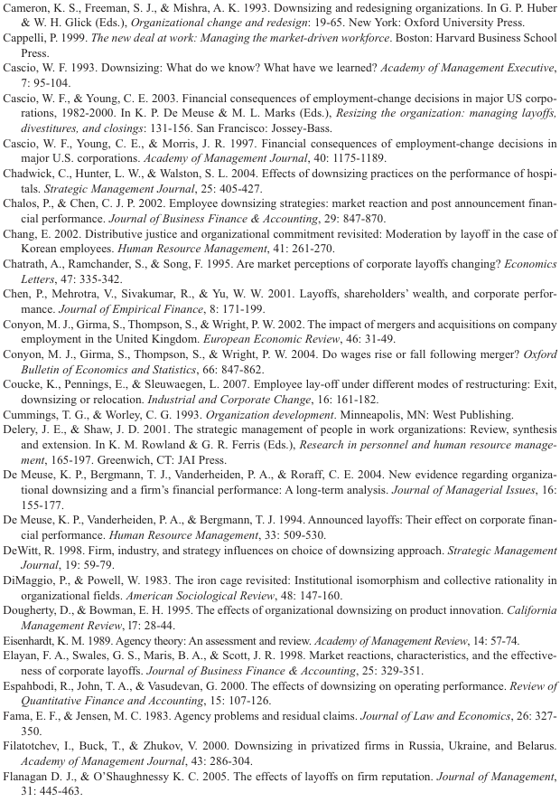

NOTE: figure/graphic rendered as an image from the PDF; its content is not machine-readable text. Caption (if any) follows as the next block.

**text found inside the figure**

Cameron, K. S., Freeman, S. J., & Mishra, A. K. 1993. Downsizing and redesigning organizations. In G. P. Huber

& W. H. Glick (Eds.), *Organizational change and redesign*: 19-65. New York: Oxford University Press. Cappelli, P. 1999. *The new deal at work: Managing the market-driven workforce*. Boston: Harvard Business School

Press. Cascio, W. F. 1993. Downsizing: What do we know? What have we learned? *Academy of Management Executive*,

7: 95-104. Cascio, W. F., & Young, C. E. 2003. Financial consequences of employment-change decisions in major US corpo-

rations, 1982-2000. In K. P. De Meuse & M. L. Marks (Eds.), *Resizing the organization: managing layoffs, divestitures, and closings*: 131-156. San Francisco: Jossey-Bass. Cascio, W. F., Young, C. E., & Morris, J. R. 1997. Financial consequences of employment-change decisions in

major U.S. corporations. *Academy of Management Journal*, 40: 1175-1189. Chadwick, C., Hunter, L. W., & Walston, S. L. 2004. Effects of downsizing practices on the performance of hospi-

tals. *Strategic Management Journal*, 25: 405-427. Chalos, P., & Chen, C. J. P. 2002. Employee downsizing strategies: market reaction and post announcement finan-

cial performance. *Journal of Business Finance & Accounting*, 29: 847-870. Chang, E. 2002. Distributive justice and organizational commitment revisited: Moderation by layoff in the case of

Korean employees. *Human Resource Management*, 41: 261-270. Chatrath, A., Ramchander, S., & Song, F. 1995. Are market perceptions of corporate layoffs changing? *Economics*

*Letters*, 47: 335-342. Chen, P., Mehrotra, V., Sivakumar, R., & Yu, W. W. 2001. Layoffs, shareholders’ wealth, and corporate perfor-

mance. *Journal of Empirical Finance*, 8: 171-199. Conyon, M. J., Girma, S., Thompson, S., & Wright, P. W. 2002. The impact of mergers and acquisitions on company

employment in the United Kingdom. *European Economic Review*, 46: 31-49. Conyon, M. J., Girma, S., Thompson, S., & Wright, P. W. 2004. Do wages rise or fall following merger? *Oxford*

*Bulletin of Economics and Statistics*, 66: 847-862. Coucke, K., Pennings, E., & Sleuwaegen, L. 2007. Employee lay-off under different modes of restructuring: Exit,

downsizing or relocation. *Industrial and Corporate Change*, 16: 161-182. Cummings, T. G., & Worley, C. G. 1993. *Organization development*. Minneapolis, MN: West Publishing. Delery, J. E., & Shaw, J. D. 2001. The strategic management of people in work organizations: Review, synthesis

and extension. In K. M. Rowland & G. R. Ferris (Eds.), *Research in personnel and human resource management*, 165-197. Greenwich, CT: JAI Press. De Meuse, K. P., Bergmann, T. J., Vanderheiden, P. A., & Roraff, C. E. 2004. New evidence regarding organiza-

tional downsizing and a firm’s financial performance: A long-term analysis. *Journal of Managerial Issues*, 16: 155-177. De Meuse, K. P., Vanderheiden, P. A., & Bergmann, T. J. 1994. Announced layoffs: Their effect on corporate finan-

cial performance. *Human Resource Management*, 33: 509-530. DeWitt, R. 1998. Firm, industry, and strategy influences on choice of downsizing approach. *Strategic Management*

*Journal*, 19: 59-79. DiMaggio, P., & Powell, W. 1983. The iron cage revisited: Institutional isomorphism and collective rationality in

organizational fields. *American Sociological Review*, 48: 147-160. Dougherty, D., & Bowman, E. H. 1995. The effects of organizational downsizing on product innovation. *California*

*Management Review*, l7: 28-44. Eisenhardt, K. M. 1989. Agency theory: An assessment and review. *Academy of Management Review*, 14: 57-74. Elayan, F. A., Swales, G. S., Maris, B. A., & Scott, J. R. 1998. Market reactions, characteristics, and the effective-

ness of corporate layoffs. *Journal of Business Finance & Accounting*, 25: 329-351. Espahbodi, R., John, T. A., & Vasudevan, G. 2000. The effects of downsizing on operating performance. *Review of*

*Quantitative Finance and Accounting*, 15: 107-126. Fama, E. F., & Jensen, M. C. 1983. Agency problems and residual claims. *Journal of Law and Economics*, 26: 327-

350. Filatotchev, I., Buck, T., & Zhukov, V. 2000. Downsizing in privatized firms in Russia, Ukraine, and Belarus.

*Academy of Management Journal*, 43: 286-304. Flanagan D. J., & O’Shaughnessy K. C. 2005. The effects of layoffs on firm reputation. *Journal of Management*,

31: 445-463.

Page 66

346 Journal of Management / January 2010

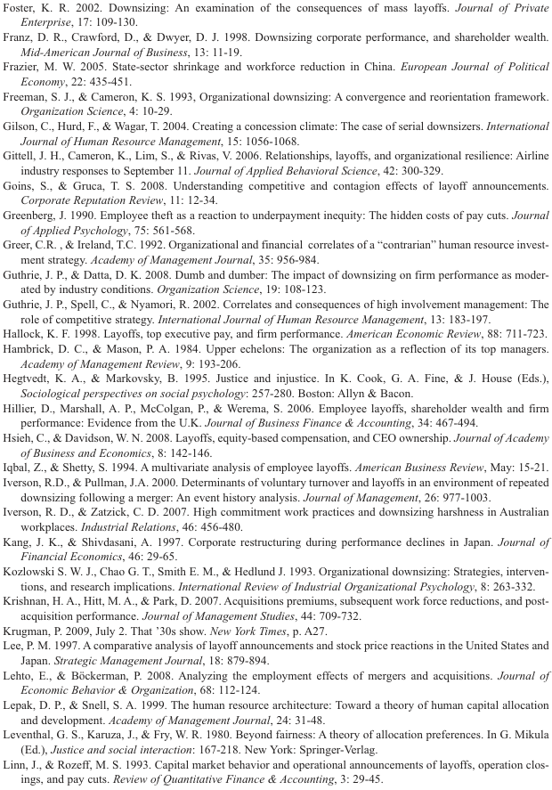

NOTE: figure/graphic rendered as an image from the PDF; its content is not machine-readable text. Caption (if any) follows as the next block.

**text found inside the figure**

Foster, K. R. 2002. Downsizing: An examination of the consequences of mass layoffs. *Journal of Private*

*Enterprise*, 17: 109-130. Franz, D. R., Crawford, D., & Dwyer, D. J. 1998. Downsizing corporate performance, and shareholder wealth.

*Mid-American Journal of Business*, 13: 11-19. Frazier, M. W. 2005. State-sector shrinkage and workforce reduction in China. *European Journal of Political*

*Economy*, 22: 435-451. Freeman, S. J., & Cameron, K. S. 1993, Organizational downsizing: A convergence and reorientation framework.

*Organization Science*, 4: 10-29. Gilson, C., Hurd, F., & Wagar, T. 2004. Creating a concession climate: The case of serial downsizers. *International*

*Journal of Human Resource Management*, 15: 1056-1068. Gittell, J. H., Cameron, K., Lim, S., & Rivas, V. 2006. Relationships, layoffs, and organizational resilience: Airline

industry responses to September 11. *Journal of Applied Behavioral Science*, 42: 300-329. Goins, S., & Gruca, T. S. 2008. Understanding competitive and contagion effects of layoff announcements.

*Corporate Reputation Review*, 11: 12-34. Greenberg, J. 1990. Employee theft as a reaction to underpayment inequity: The hidden costs of pay cuts. *Journal*

*of Applied Psychology*, 75: 561-568. Greer, C.R. , & Ireland, T.C. 1992. Organizational and financial correlates of a “contrarian” human resource invest-

ment strategy. *Academy of Management Journal*, 35: 956-984. Guthrie, J. P., & Datta, D. K. 2008. Dumb and dumber: The impact of downsizing on firm performance as moder-

ated by industry conditions. *Organization Science*, 19: 108-123. Guthrie, J. P., Spell, C., & Nyamori, R. 2002. Correlates and consequences of high involvement management: The

role of competitive strategy. *International Journal of Human Resource Management*, 13: 183-197. Hallock, K. F. 1998. Layoffs, top executive pay, and firm performance. *American Economic Review*, 88: 711-723. Hambrick, D. C., & Mason, P. A. 1984. Upper echelons: The organization as a reflection of its top managers.

*Academy of Management Review*, 9: 193-206. Hegtvedt, K. A., & Markovsky, B. 1995. Justice and injustice. In K. Cook, G. A. Fine, & J. House (Eds.),

*Sociological perspectives on social psychology*: 257-280. Boston: Allyn & Bacon. Hillier, D., Marshall, A. P., McColgan, P., & Werema, S. 2006. Employee layoffs, shareholder wealth and firm

performance: Evidence from the U.K. *Journal of Business Finance & Accounting*, 34: 467-494. Hsieh, C., & Davidson, W. N. 2008. Layoffs, equity-based compensation, and CEO ownership. *Journal of Academy*

*of Business and Economics*, 8: 142-146. Iqbal, Z., & Shetty, S. 1994. A multivariate analysis of employee layoffs. *American Business Review*, May: 15-21. Iverson, R.D., & Pullman, J.A. 2000. Determinants of voluntary turnover and layoffs in an environment of repeated

downsizing following a merger: An event history analysis. *Journal of Management*, 26: 977-1003. Iverson, R. D., & Zatzick, C. D. 2007. High commitment work practices and downsizing harshness in Australian

workplaces. *Industrial Relations*, 46: 456-480. Kang, J. K., & Shivdasani, A. 1997. Corporate restructuring during performance declines in Japan. *Journal of*

*Financial Economics*, 46: 29-65. Kozlowski S. W. J., Chao G. T., Smith E. M., & Hedlund J. 1993. Organizational downsizing: Strategies, interven-

tions, and research implications. *International Review of Industrial Organizational Psychology*, 8: 263-332. Krishnan, H. A., Hitt, M. A., & Park, D. 2007. Acquisitions premiums, subsequent work force reductions, and post-

acquisition performance. *Journal of Management Studies*, 44: 709-732. Krugman, P. 2009, July 2. That ’30s show. *New York Times*, p. A27. Lee, P. M. 1997. A comparative analysis of layoff announcements and stock price reactions in the United States and

Japan. *Strategic Management Journal*, 18: 879-894. Lehto, E., & Böckerman, P. 2008. Analyzing the employment effects of mergers and acquisitions. *Journal of*

*Economic Behavior & Organization*, 68: 112-124. Lepak, D. P., & Snell, S. A. 1999. The human resource architecture: Toward a theory of human capital allocation

and development. *Academy of Management Journal*, 24: 31-48. Leventhal, G. S., Karuza, J., & Fry, W. R. 1980. Beyond fairness: A theory of allocation preferences. In G. Mikula

(Ed.), *Justice and social interaction*: 167-218. New York: Springer-Verlag. Linn, J., & Rozeff, M. S. 1993. Capital market behavior and operational announcements of layoffs, operation clos-

ings, and pay cuts. *Review of Quantitative Finance & Accounting*, 3: 29-45.

Page 67

Datta et al. / Causes and Effects of Employee Downsizing 347

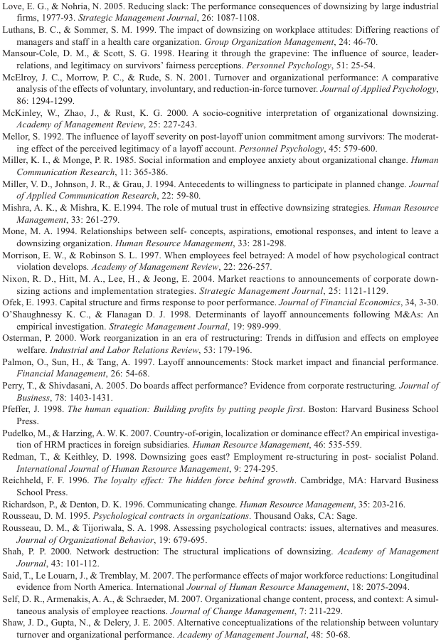

NOTE: figure/graphic rendered as an image from the PDF; its content is not machine-readable text. Caption (if any) follows as the next block.

**text found inside the figure**

Love, E. G., & Nohria, N. 2005. Reducing slack: The performance consequences of downsizing by large industrial

firms, 1977-93. *Strategic Management Journal*, 26: 1087-1108. Luthans, B. C., & Sommer, S. M. 1999. The impact of downsizing on workplace attitudes: Differing reactions of

managers and staff in a health care organization. *Group Organization Management*, 24: 46-70. Mansour-Cole, D. M., & Scott, S. G. 1998. Hearing it through the grapevine: The influence of source, leader-

relations, and legitimacy on survivors’ fairness perceptions. *Personnel Psychology*, 51: 25-54. McElroy, J. C., Morrow, P. C., & Rude, S. N. 2001. Turnover and organizational performance: A comparative

analysis of the effects of voluntary, involuntary, and reduction-in-force turnover. *Journal of Applied Psychology*, 86: 1294-1299. McKinley, W., Zhao, J., & Rust, K. G. 2000. A socio-cognitive interpretation of organizational downsizing.

*Academy of Management Review*, 25: 227-243. Mellor, S. 1992. The influence of layoff severity on post-layoff union commitment among survivors: The moderat-

ing effect of the perceived legitimacy of a layoff account. *Personnel Psychology*, 45: 579-600. Miller, K. I., & Monge, P. R. 1985. Social information and employee anxiety about organizational change. *Human*

*Communication Research*, 11: 365-386. Miller, V. D., Johnson, J. R., & Grau, J. 1994. Antecedents to willingness to participate in planned change. *Journal*

*of Applied Communication Research*, 22: 59-80. Mishra, A. K., & Mishra, K. E.1994. The role of mutual trust in effective downsizing strategies. *Human Resource*

*Management*, 33: 261-279. Mone, M. A. 1994. Relationships between self- concepts, aspirations, emotional responses, and intent to leave a

downsizing organization. *Human Resource Management*, 33: 281-298. Morrison, E. W., & Robinson S. L. 1997. When employees feel betrayed: A model of how psychological contract

violation develops. *Academy of Management Review*, 22: 226-257. Nixon, R. D., Hitt, M. A., Lee, H., & Jeong, E. 2004. Market reactions to announcements of corporate down-

sizing actions and implementation strategies. *Strategic Management Journal*, 25: 1121-1129. Ofek, E. 1993. Capital structure and firms response to poor performance. *Journal of Financial Economics*, 34, 3-30. O’Shaughnessy K. C., & Flanagan D. J. 1998. Determinants of layoff announcements following M&As: An

empirical investigation. *Strategic Management Journal*, 19: 989-999. Osterman, P. 2000. Work reorganization in an era of restructuring: Trends in diffusion and effects on employee

welfare. *Industrial and Labor Relations Review*, 53: 179-196. Palmon, O., Sun, H., & Tang, A. 1997. Layoff announcements: Stock market impact and financial performance.

*Financial Management*, 26: 54-68. Perry, T., & Shivdasani, A. 2005. Do boards affect performance? Evidence from corporate restructuring. *Journal of*

*Business*, 78: 1403-1431. Pfeffer, J. 1998. *The human equation: Building profits by putting people first*. Boston: Harvard Business School

Press. Pudelko, M., & Harzing, A. W. K. 2007. Country-of-origin, localization or dominance effect? An empirical investiga-

tion of HRM practices in foreign subsidiaries. *Human Resource Management*, 46: 535-559. Redman, T., & Keithley, D. 1998. Downsizing goes east? Employment re-structuring in post- socialist Poland.

*International Journal of Human Resource Management*, 9: 274-295. Reichheld, F. F. 1996. *The loyalty effect: The hidden force behind growth*. Cambridge, MA: Harvard Business

School Press. Richardson, P., & Denton, D. K. 1996. Communicating change. *Human Resource Management*, 35: 203-216. Rousseau, D. M. 1995. *Psychological contracts in organizations*. Thousand Oaks, CA: Sage. Rousseau, D. M., & Tijoriwala, S. A. 1998. Assessing psychological contracts: issues, alternatives and measures.

*Journal of Organizational Behavior*, 19: 679-695. Shah, P. P. 2000. Network destruction: The structural implications of downsizing. *Academy of Management*

*Journal*, 43: 101-112. Said, T., Le Louarn, J., & Tremblay, M. 2007. The performance effects of major workforce reductions: Longitudinal

evidence from North America. International *Journal of Human Resource Management*, 18: 2075-2094. Self, D. R., Armenakis, A. A., & Schraeder, M. 2007. Organizational change content, process, and context: A simul-

taneous analysis of employee reactions. *Journal of Change Management*, 7: 211-229. Shaw, J. D., Gupta, N., & Delery, J. E. 2005. Alternative conceptualizations of the relationship between voluntary

turnover and organizational performance. *Academy of Management Journal*, 48: 50-68.

Page 68

348 Journal of Management / January 2010

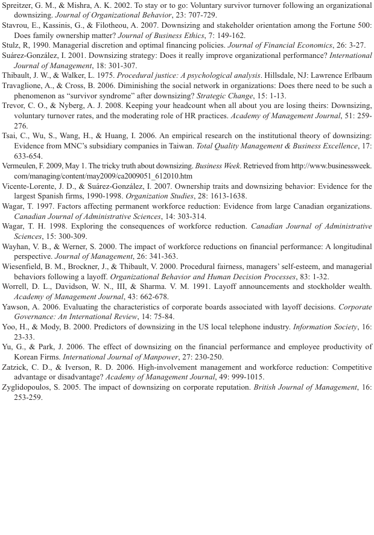

NOTE: figure/graphic rendered as an image from the PDF; its content is not machine-readable text. Caption (if any) follows as the next block.

**text found inside the figure**

Spreitzer, G. M., & Mishra, A. K. 2002. To stay or to go: Voluntary survivor turnover following an organizational

downsizing. *Journal of Organizational Behavior*, 23: 707-729. Stavrou, E., Kassinis, G., & Filotheou, A. 2007. Downsizing and stakeholder orientation among the Fortune 500:

Does family ownership matter? *Journal of Business Ethics*, 7: 149-162. Stulz, R, 1990. Managerial discretion and optimal financing policies. *Journal of Financial Economics*, 26: 3-27. Suárez-González, I. 2001. Downsizing strategy: Does it really improve organizational performance? *International*

*Journal of Management*, 18: 301-307. Thibault, J. W., & Walker, L. 1975. *Procedural justice: A psychological analysis*. Hillsdale, NJ: Lawrence Erlbaum Travaglione, A., & Cross, B. 2006. Diminishing the social network in organizations: Does there need to be such a

phenomenon as “survivor syndrome” after downsizing? *Strategic Change*, 15: 1-13. Trevor, C. O., & Nyberg, A. J. 2008. Keeping your headcount when all about you are losing theirs: Downsizing,

voluntary turnover rates, and the moderating role of HR practices. *Academy of Management Journal*, 51: 259- 276. Tsai, C., Wu, S., Wang, H., & Huang, I. 2006. An empirical research on the institutional theory of downsizing:

Evidence from MNC’s subsidiary companies in Taiwan. *Total Quality Management & Business Excellence*, 17: 633-654. Vermeulen, F. 2009, May 1. The tricky truth about downsizing. *Business Week*. Retrieved from http://www.businessweek.

com/managing/content/may2009/ca2009051_612010.htm Vicente-Lorente, J. D., & Suárez-González, I. 2007. Ownership traits and downsizing behavior: Evidence for the

largest Spanish firms, 1990-1998. *Organization Studies*, 28: 1613-1638. Wagar, T. 1997. Factors affecting permanent workforce reduction: Evidence from large Canadian organizations.

*Canadian Journal of Administrative Sciences*, 14: 303-314. Wagar, T. H. 1998. Exploring the consequences of workforce reduction. *Canadian Journal of Administrative*

*Sciences*, 15: 300-309. Wayhan, V. B., & Werner, S. 2000. The impact of workforce reductions on financial performance: A longitudinal

perspective. *Journal of Management*, 26: 341-363. Wiesenfield, B. M., Brockner, J., & Thibault, V. 2000. Procedural fairness, managers’ self-esteem, and managerial

behaviors following a layoff. *Organizational Behavior and Human Decision Processes*, 83: 1-32. Worrell, D. L., Davidson, W. N., III, & Sharma. V. M. 1991. Layoff announcements and stockholder wealth.

*Academy of Management Journal*, 43: 662-678. Yawson, A. 2006. Evaluating the characteristics of corporate boards associated with layoff decisions. *Corporate*

*Governance: An International Review*, 14: 75-84. Yoo, H., & Mody, B. 2000. Predictors of downsizing in the US local telephone industry. *Information Society*, 16:

23-33. Yu, G., & Park, J. 2006. The effect of downsizing on the financial performance and employee productivity of

Korean Firms. *International Journal of Manpower*, 27: 230-250. Zatzick, C. D., & Iverson, R. D. 2006. High-involvement management and workforce reduction: Competitive

advantage or disadvantage? *Academy of Management Journal*, 49: 999-1015. Zyglidopoulos, S. 2005. The impact of downsizing on corporate reputation. *British Journal of Management*, 16:

253-259.